# Differential abundance analysis — T2D vs Healthy (Chinese cohort)

Anton

2026-05-30

```r
knitr::opts_knit$set(root.dir = rprojroot::find_rstudio_root_file())
knitr::opts_chunk$set(echo = TRUE, message = FALSE, warning = FALSE)
```

This Rmd mirrors the structure of the Week 21 practical (Antton Alberdi’s reference Rmd), adapted to the T2D vs Healthy comparison within the filtered Chinese cohort (`Project.ID == "PRJNA422434"`).

| Teacher’s variable | Used here |
| --- | --- |
| `body_site == "gut"` | (already filtered to Chinese cohort; no body-site variable) |
| `age` (adult, infant) | `Disease.MESH.ID` (D003924 = T2D, D006262 = Healthy) |
| `status` (healthy, sick) | `Sex` (Female, Male) — used as adjustment covariate |
| `genus`, `species` (lowercase) | `Genus`, `Species` (uppercase) — note: the `Species` column in this dataset actually contains genus names (column-shift quirk) |

Direction convention throughout: **positive** estimate = T2D-enriched, **negative** estimate = T2D-depleted (= Healthy-enriched).

## Loading of required libraries

```r
library(phyloseq)
library(vegan)
library(dplyr)
library(tibble)
library(tidyr)
library(stringr)
library(ggplot2)
library(ggh4x)
library(broom)
library(microbiome)
```

> *Taught in: W21 reference Rmd (Alberdi, `week21_differential_abundance/differential_abundance.Rmd`) §1 “Loading of required libraries”. Same phyloseq + vegan + tidyverse + microbiome stack; `lme4`/`lmerTest`/`broom.mixed`/`purrr` dropped because no mixed models are used here.*

## Load and inspect the data

```r
load("project/data/D003924_Diabetes_Mellitus,_T/genus/phyloseq.RData")
ps <- subset_samples(pylsq, Project.ID == "PRJNA422434")
rm(pylsq)

ps
```

```
## phyloseq-class experiment-level object
## otu_table()   OTU Table:         [ 58 taxa and 359 samples ]
## sample_data() Sample Data:       [ 359 samples by 12 sample variables ]
## tax_table()   Taxonomy Table:    [ 58 taxa by 7 taxonomic ranks ]
## phy_tree()    Phylogenetic Tree: [ 58 tips and 27 internal nodes ]
```

```r
sample_variables(ps)
```

```
##  [1] "Run.ID"                 "Project.ID"             "Experiment.type"
##  [4] "Nr..reads.sequenced"    "Country"                "Sex"
##  [7] "Host.age"               "BMI"                    "Recent.antibiotics.use"
## [10] "Disease.MESH.ID"        "Disease.name"           "QC.status"
```

```r
rank_names(ps)
```

```
## [1] "Domain"  "Phylum"  "Class"   "Order"   "Family"  "Genus"   "Species"
```

```r
table(sample_data(ps)$Disease.MESH.ID)
```

```
##
## D003924 D006262
##     187     172
```

> *Taught in: W21 reference Rmd §1 “Load and inspect the data” (`readRDS` → `ps`, `rank_names`, `sample_variables`, group table). Cohort filtering via `subset_samples` is taught in W20-01.*

Expected: 187 T2D + 172 Healthy = 359 samples, all from PRJNA422434.

## Visualise community composition

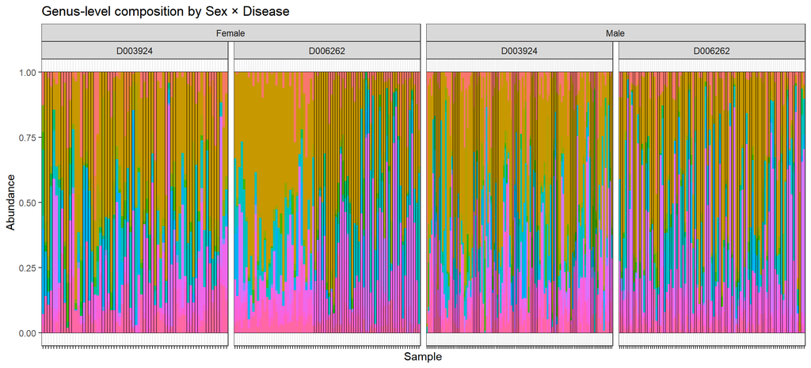

```r
ps_rel  <- transform_sample_counts(ps, function(x) x / sum(x))
otu_rel <- as(otu_table(ps_rel), "matrix") %>% t() %>% as.data.frame()
meta_rel <- data.frame(sample_data(ps_rel))
tax_rel  <- as(tax_table(ps_rel), "matrix") %>% as.data.frame()

plot_bar(ps_rel, fill = "Species") +
  geom_bar(aes(fill = Species), stat = "identity", colour = NA) +
  facet_nested(~ Sex + Disease.MESH.ID, scales = "free_x") +
  theme_bw() +
  theme(axis.text.x = element_blank(),
        legend.position = "none") +
  labs(title = "Genus-level composition by Sex × Disease",
       fill = "Genus")
```

> *Taught in: W21 reference Rmd §2 “Visualise community composition” (`transform_sample_counts` to relative abundance, `plot_bar`, `facet_nested`). The reference’s `tax_glom` step is omitted because the data is already genus-level.*

The data is already at genus level (58 taxa) — no `tax_glom` needed. Legend hidden because 58 categories are unreadable.

```r
dat_rel <- otu_rel %>%
  rownames_to_column("sample_id") %>%
  pivot_longer(-sample_id, names_to = "taxon", values_to = "rel_abund") %>%
  left_join(meta_rel %>% rownames_to_column("sample_id"), by = "sample_id") %>%
  left_join(tax_rel  %>% rownames_to_column("taxon"),     by = "taxon")
```

> *Taught in: W21 reference Rmd §2 (the hidden chunk that builds the long `dat_rel` table used by all relative-abundance analyses).*

# Univariate statistics

## Explore individual taxa

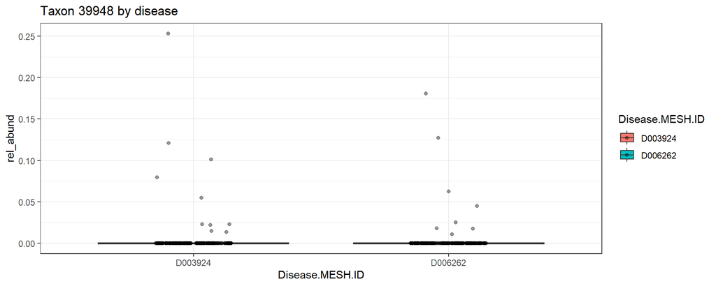

```r
one_taxon <- unique(dat_rel$taxon)[3]
# one_taxon <- unique(dat_rel$taxon)[5]
# one_taxon <- unique(dat_rel$taxon)[20]

# Comparison between disease groups
dat_rel %>%
  filter(taxon == one_taxon) %>%
  ggplot(aes(x = Disease.MESH.ID, y = rel_abund, fill = Disease.MESH.ID)) +
    geom_boxplot(outlier.shape = NA) +
    geom_jitter(width = 0.15, alpha = 0.4) +
    theme_bw() +
    labs(title = paste("Taxon", one_taxon, "by disease"))
```

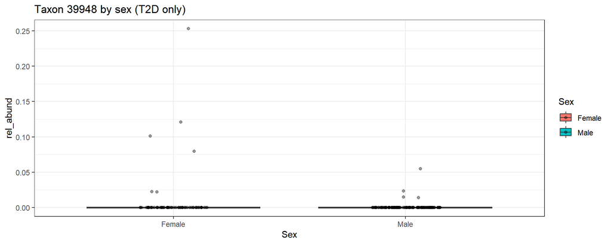

```r
# Comparison between sexes within T2D
dat_rel %>%
  filter(taxon == one_taxon, Disease.MESH.ID == "D003924") %>%
  ggplot(aes(x = Sex, y = rel_abund, fill = Sex)) +
    geom_boxplot(outlier.shape = NA) +
    geom_jitter(width = 0.15, alpha = 0.4) +
    theme_bw() +
    labs(title = paste("Taxon", one_taxon, "by sex (T2D only)"))
```

> *Taught in: W21 reference Rmd §3 “Explore individual taxa” (pick one taxon, boxplot + jitter across the grouping variable, then across a second variable). Here the grouping variable is Disease and the second is Sex, mirroring the reference’s age/body-site pair.*

## Diagnose the data before testing

### Zero-inflation

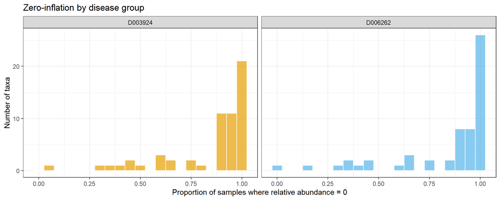

```r
dat_rel %>%
  group_by(taxon, Disease.MESH.ID) %>%
  summarise(prop_zero = mean(rel_abund == 0), .groups = "drop") %>%
  ggplot(aes(x = prop_zero, fill = Disease.MESH.ID)) +
    geom_histogram(binwidth = 0.05, color = "white", alpha = 0.7) +
    scale_fill_manual(values = c("D003924" = "#E69F00", "D006262" = "#56B4E9")) +
    facet_wrap(~ Disease.MESH.ID) +
    labs(x = "Proportion of samples where relative abundance = 0",
         y = "Number of taxa",
         title = "Zero-inflation by disease group") +
    theme_bw() +
    theme(legend.position = "none")
```

> *Taught in: W21 reference Rmd §4 “Diagnose the data before testing” (zero-inflation histogram). Also Alberdi reading “Multivariate statistics and multiple correction” §2 (zero inflation as one of the three problems that break t-tests). Faceting by Disease is a project addition for visual comparison.*

### Right skew on a sample of mid-prevalence taxa

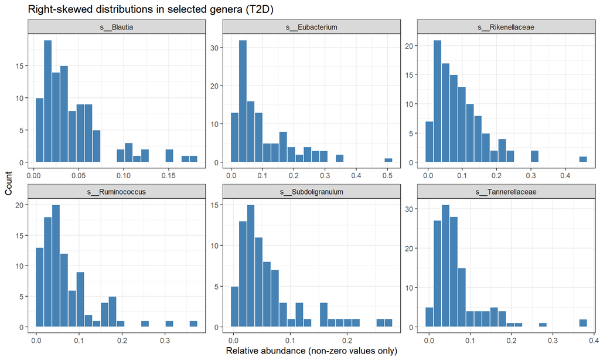

```r
set.seed(42)
example_taxa <- dat_rel %>%
  filter(Disease.MESH.ID == "D003924") %>%
  group_by(taxon, Genus, Species) %>%
  summarise(prop_nonzero = mean(rel_abund > 0), .groups = "drop") %>%
  filter(prop_nonzero > 0.4, prop_nonzero < 0.9) %>%
  slice_sample(n = 6) %>%
  pull(taxon)

dat_rel %>%
  filter(Disease.MESH.ID == "D003924",
         taxon %in% example_taxa,
         rel_abund > 0) %>%
  mutate(label = Species) %>%
  ggplot(aes(x = rel_abund)) +
    geom_histogram(bins = 20, fill = "steelblue", color = "white") +
    facet_wrap(~ label, scales = "free") +
    labs(x = "Relative abundance (non-zero values only)",
         y = "Count",
         title = "Right-skewed distributions in selected genera (T2D)") +
    theme_bw()
```

> *Taught in: W21 reference Rmd §4 (right-skew histograms on mid-prevalence example taxa, same `set.seed(42)` + `prop_nonzero` 0.4–0.9 sampling). Also Alberdi reading §2 (right skew).*

### Q-Q plots

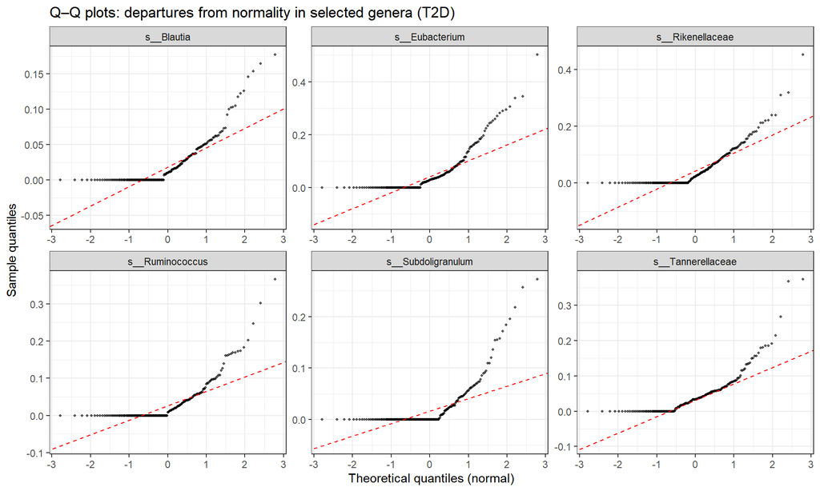

```r
dat_rel %>%
  filter(Disease.MESH.ID == "D003924", taxon %in% example_taxa) %>%
  mutate(label = Species) %>%
  ggplot(aes(sample = rel_abund)) +
    stat_qq(size = 0.8, alpha = 0.6) +
    stat_qq_line(color = "red", linetype = "dashed") +
    facet_wrap(~ label, scales = "free") +
    labs(x = "Theoretical quantiles (normal)",
         y = "Sample quantiles",
         title = "Q–Q plots: departures from normality in selected genera (T2D)") +
    theme_bw()
```

> *Taught in: W21 reference Rmd §4 (Q–Q plots vs a normal line). Also Alberdi reading §2 (non-normality, the third assumption violation).*

Zero-inflation, right skew and Q-Q curvature together justify rank-based or compositional methods over raw t-tests.

## Wilcoxon rank-sum test

```r
wilcox_results <- dat_rel %>%
  group_by(taxon, Genus, Species) %>%
  summarise(
    p_value      = wilcox.test(rel_abund ~ Disease.MESH.ID, exact = FALSE)$p.value,
    mean_T2D     = mean(rel_abund[Disease.MESH.ID == "D003924"]),
    mean_Healthy = mean(rel_abund[Disease.MESH.ID == "D006262"]),
    log2_fc      = log2((mean_T2D + 1e-6) / (mean_Healthy + 1e-6)),
    .groups = "drop"
  ) %>%
  mutate(q_value = p.adjust(p_value, method = "BH"))

head(wilcox_results, 10)
```

```
## # A tibble: 10 × 8
##    taxon   Genus          Species  p_value mean_T2D mean_Healthy log2_fc q_value
##    <chr>   <chr>          <chr>      <dbl>    <dbl>        <dbl>   <dbl>   <dbl>
##  1 100883  g__Erysipelot… s__Cop…   0.0240 0.00182      0.000285   2.67    0.112
##  2 102106  g__Coriobacte… s__Col…   0.0630 0.00232      0.000211   3.45    0.223
##  3 1263    g__Ruminococc… s__Rum…   0.749  0.0361       0.0303     0.249   0.873
##  4 1301    g__Streptococ… s__Str…   0.930  0.00280      0.00669   -1.26    0.952
##  5 133925  g__Atopobiace… s__Ols…   0.340  0.000249     0          7.97    0.578
##  6 1348911 g__Bacteroida… s__Bar…   0.176  0.000310     0          8.28    0.487
##  7 1350    g__Enterococc… s__Ent…   0.0544 0.000817     0          9.68    0.218
##  8 135858  g__Erysipelot… s__Cat… NaN      0            0          0     NaN
##  9 1485    g__Clostridia… s__Clo…   0.407  0.0245       0.0115     1.09    0.633
## 10 156454  g__Veillonell… s__Ana…   0.340  0.000144     0          7.18    0.578
```

> *Taught in: W21 reference Rmd §5 “Wilcoxon rank-sum test” (one `wilcox.test(... ~ group, exact = FALSE)` per taxon, group means, `log2_fc`, `p.adjust(method = "BH")`). BH/FDR also Alberdi reading §6 and W20-02. Wilcoxon-over-t-test rationale: Alberdi reading §3.*

`log2_fc > 0` → T2D-enriched. `log2_fc < 0` → T2D-depleted.

### Top T2D-depleted (Wilcoxon)

```r
wilcox_T2D_depleted <- wilcox_results %>%
  select(taxon, Genus, Species, mean_T2D, mean_Healthy, log2_fc, p_value, q_value) %>%
  arrange(log2_fc) %>%
  head(10)

wilcox_T2D_depleted
```

```
## # A tibble: 10 × 8
##    taxon  Genus            Species mean_T2D mean_Healthy log2_fc p_value q_value
##    <chr>  <chr>            <chr>      <dbl>        <dbl>   <dbl>   <dbl>   <dbl>
##  1 544    g__Citrobacter   s__      0         0.000174    -7.45  0.0706   0.233
##  2 846    g__Oxalobacter   s__      0         0.0000784   -6.31  0.300    0.578
##  3 46255  g__Leuconostoca… s__Wei…  1.45e-6   0.0000837   -5.11  0.953    0.953
##  4 581    g__Morganella    s__      0         0.00000915  -3.34  0.300    0.578
##  5 946234 g__Ruminococcac… s__Fla…  6.23e-5   0.000232    -1.88  0.512    0.736
##  6 724    g__Haemophilus   s__      1.60e-3   0.00429     -1.42  0.0162   0.0825
##  7 1301   g__Streptococca… s__Str…  2.80e-3   0.00669     -1.26  0.930    0.952
##  8 838    g__Bacteroidales s__Pre…  6.76e-2   0.149       -1.14  0.00222  0.0177
##  9 189330 g__Lachnospirac… s__Dor…  1.13e-3   0.00242     -1.10  0.365    0.601
## 10 40544  g__Sutterella    s__      9.47e-4   0.00185     -0.969 0.634    0.789
```

> *Taught in: W21 reference Rmd §5 (top-ranked table by `log2_fc`, here the depleted = Healthy-enriched tail).*

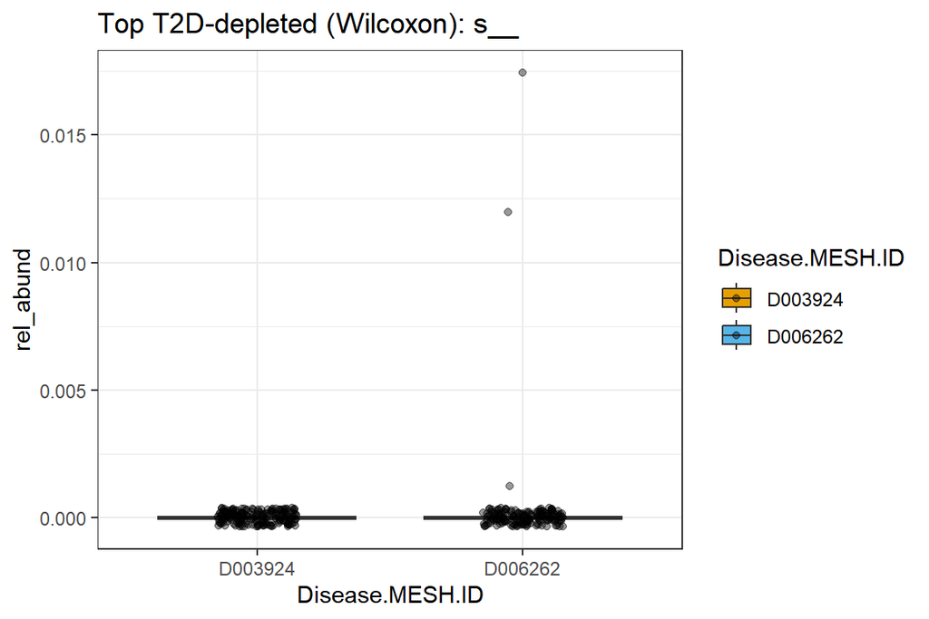

```r
top_taxon <- wilcox_T2D_depleted %>% slice(1) %>% pull(taxon)
top_label <- wilcox_T2D_depleted %>% slice(1) %>% pull(Species)

dat_rel %>%
  filter(taxon == top_taxon) %>%
  ggplot(aes(x = Disease.MESH.ID, y = rel_abund, fill = Disease.MESH.ID)) +
    geom_boxplot(outlier.shape = NA) +
    geom_jitter(width = 0.15, alpha = 0.4) +
    scale_fill_manual(values = c("D003924" = "#E69F00", "D006262" = "#56B4E9")) +
    theme_bw() +
    labs(title = paste("Top T2D-depleted (Wilcoxon):", top_label))
```

> *Taught in: W21 reference Rmd §5 (raw boxplot + jitter of the top hit, to eyeball that the test direction matches the data).*

### Top T2D-enriched (Wilcoxon)

```r
wilcox_T2D_enriched <- wilcox_results %>%
  select(taxon, Genus, Species, mean_T2D, mean_Healthy, log2_fc, p_value, q_value) %>%
  arrange(-log2_fc) %>%
  head(10)

wilcox_T2D_enriched
```

```
## # A tibble: 10 × 8
##    taxon   Genus           Species mean_T2D mean_Healthy log2_fc p_value q_value
##    <chr>   <chr>           <chr>      <dbl>        <dbl>   <dbl>   <dbl>   <dbl>
##  1 1350    g__Enterococca… s__Ent…  8.17e-4     0           9.68 5.44e-2 2.18e-1
##  2 207244  g__Lachnospira… s__Ana…  4.25e-4     0           8.73 1.06e-2 5.92e-2
##  3 1348911 g__Bacteroidal… s__Bar…  3.10e-4     0           8.28 1.76e-1 4.87e-1
##  4 133925  g__Atopobiaceae s__Ols…  2.49e-4     0           7.97 3.40e-1 5.78e-1
##  5 156454  g__Veillonella… s__Ana…  1.44e-4     0           7.18 3.40e-1 5.78e-1
##  6 244127  g__Ruminococca… s__Ana…  5.89e-5     0           5.90 3.40e-1 5.78e-1
##  7 583     g__Proteus      s__      1.62e-5     0           4.11 3.40e-1 5.78e-1
##  8 61170   g__Erysipelotr… s__Hol…  1.58e-5     0           4.07 3.40e-1 5.78e-1
##  9 102106  g__Coriobacter… s__Col…  2.32e-3     0.000211    3.45 6.30e-2 2.23e-1
## 10 1578    g__Lactobacill… s__Lac…  1.23e-2     0.00138     3.16 3.54e-5 9.92e-4
```

> *Taught in: W21 reference Rmd §5 (top-ranked table by `log2_fc`, here the enriched = T2D-enriched tail).*

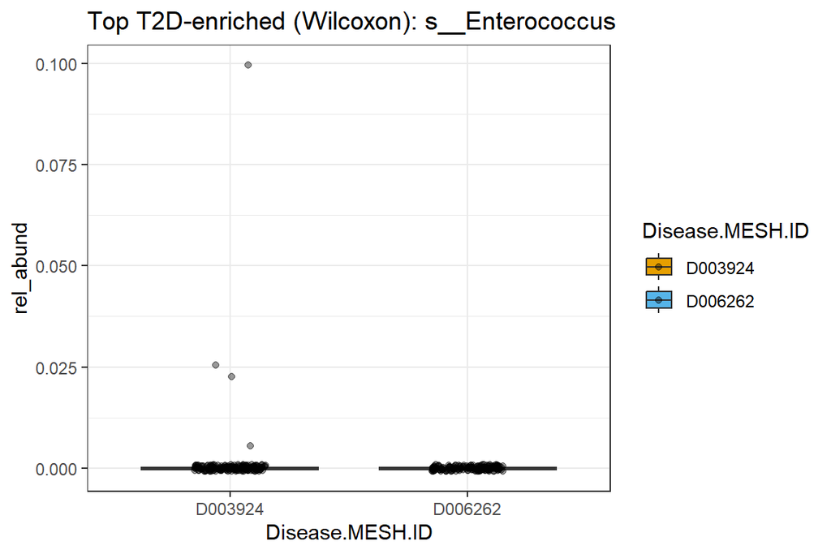

```r
top_taxon <- wilcox_T2D_enriched %>% slice(1) %>% pull(taxon)
top_label <- wilcox_T2D_enriched %>% slice(1) %>% pull(Species)

dat_rel %>%
  filter(taxon == top_taxon) %>%
  ggplot(aes(x = Disease.MESH.ID, y = rel_abund, fill = Disease.MESH.ID)) +
    geom_boxplot(outlier.shape = NA) +
    geom_jitter(width = 0.15, alpha = 0.4) +
    scale_fill_manual(values = c("D003924" = "#E69F00", "D006262" = "#56B4E9")) +
    theme_bw() +
    labs(title = paste("Top T2D-enriched (Wilcoxon):", top_label))
```

> *Taught in: W21 reference Rmd §5 (raw boxplot + jitter of the top enriched hit).*

### Volcano plot — Wilcoxon

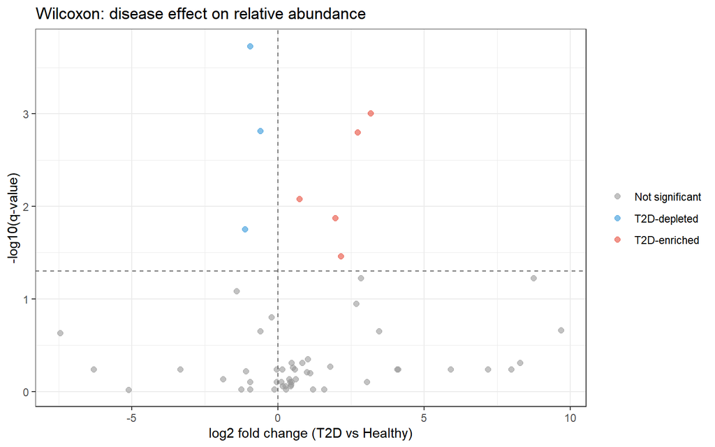

```r
wilcox_results %>%
  mutate(
    neg_log10_q = -log10(q_value),
    direction = case_when(
      q_value < 0.05 & log2_fc > 0 ~ "T2D-enriched",
      q_value < 0.05 & log2_fc < 0 ~ "T2D-depleted",
      TRUE                         ~ "Not significant"
    )
  ) %>%
  ggplot(aes(x = log2_fc, y = neg_log10_q, color = direction)) +
    geom_point(alpha = 0.6, size = 2) +
    scale_color_manual(values = c("T2D-enriched" = "#E74C3C",
                                  "T2D-depleted" = "#3498DB",
                                  "Not significant" = "grey60")) +
    geom_hline(yintercept = -log10(0.05), linetype = "dashed", color = "grey40") +
    geom_vline(xintercept = 0, linetype = "dashed", color = "grey40") +
    labs(x = "log2 fold change (T2D vs Healthy)",
         y = "-log10(q-value)", color = NULL,
         title = "Wilcoxon: disease effect on relative abundance") +
    theme_bw()
```

> *Taught in: W21 reference Rmd §5 (volcano plot: effect size on x, `-log10(q)` on y, q < 0.05 threshold line). FDR threshold: Alberdi reading §6.*

### Bar chart of top Wilcoxon hits

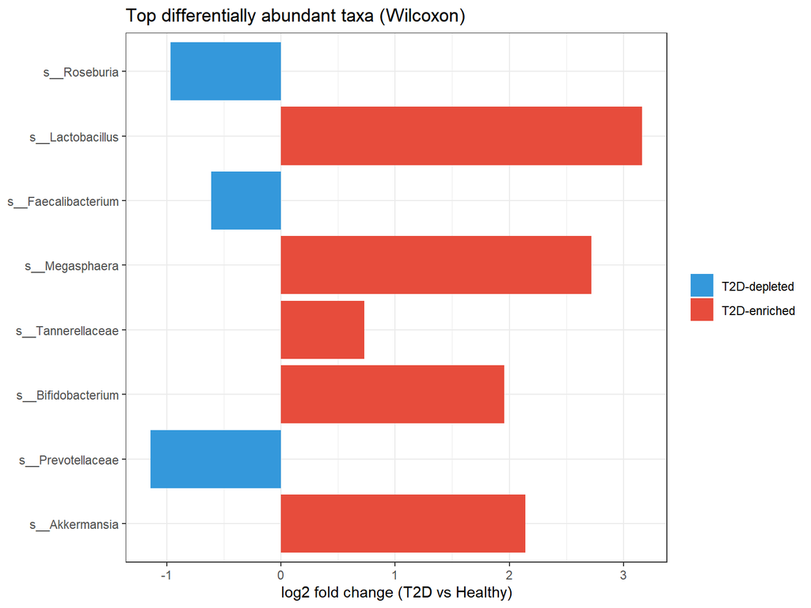

```r
bind_rows(
  wilcox_results %>% filter(q_value < 0.05) %>% arrange(log2_fc)  %>% head(10),
  wilcox_results %>% filter(q_value < 0.05) %>% arrange(-log2_fc) %>% head(10)
) %>%
  distinct() %>%
  mutate(
    label = Species,
    direction = ifelse(log2_fc > 0, "T2D-enriched", "T2D-depleted")
  ) %>%
  ggplot(aes(x = reorder(label, -q_value), y = log2_fc, fill = direction)) +
    geom_col() +
    coord_flip() +
    scale_fill_manual(values = c("T2D-enriched" = "#E74C3C", "T2D-depleted" = "#3498DB")) +
    labs(x = NULL, y = "log2 fold change (T2D vs Healthy)", fill = NULL,
         title = "Top differentially abundant taxa (Wilcoxon)") +
    theme_bw()
```

> *Taught in: W21 reference Rmd §5 (horizontal bar chart of top significant taxa ordered by q-value).*

## Disease effect using log-transformed linear models

```r
glm_disease_results <- dat_rel %>%
  mutate(Disease.MESH.ID = factor(Disease.MESH.ID, levels = c("D006262", "D003924"))) %>%
  group_by(taxon, Genus, Species) %>%
  group_modify(~ {
    fit <- glm(log10(rel_abund + 1e-6) ~ Disease.MESH.ID,
               data = .x, family = gaussian())
    broom::tidy(fit)
  }) %>%
  ungroup() %>%
  filter(term == "Disease.MESH.IDD003924") %>%
  mutate(
    q_value = p.adjust(p.value, method = "BH"),
    fold_change_T2D_vs_Healthy = 10^estimate
  )
```

> *Taught in: W21 reference Rmd §6 “Age difference using log-transformed linear models” (`glm(log10(rel_abund + 1e-6) ~ group)` per taxon via `group_modify` + `broom::tidy`, BH-adjusted, `10^estimate` = fold change). Logs + pseudocount: Alberdi reading §4; linear models: §5.*

Positive estimate = T2D-enriched on the log10 scale.

### Top T2D-depleted (GLM)

```r
glm_T2D_depleted <- glm_disease_results %>%
  select(taxon, Genus, Species, estimate, fold_change_T2D_vs_Healthy,
         std.error, statistic, p.value, q_value) %>%
  arrange(fold_change_T2D_vs_Healthy) %>%
  head(10)

glm_T2D_depleted
```

```
## # A tibble: 10 × 9
##    taxon  Genus      Species estimate fold_change_T2D_vs_H…¹ std.error statistic
##    <chr>  <chr>      <chr>      <dbl>                  <dbl>     <dbl>     <dbl>
##  1 841    g__Lachno… s__Ros…  -1.16                   0.0688     0.241    -4.83
##  2 216851 g__Rumino… s__Fae…  -0.832                  0.147      0.218    -3.81
##  3 838    g__Bacter… s__Pre…  -0.734                  0.184      0.259    -2.84
##  4 1730   g__Eubact… s__Eub…  -0.533                  0.293      0.246    -2.17
##  5 724    g__Haemop… s__      -0.297                  0.505      0.123    -2.41
##  6 1263   g__Rumino… s__Rum…  -0.283                  0.521      0.247    -1.15
##  7 33042  g__Lachno… s__Cop…  -0.261                  0.548      0.140    -1.86
##  8 570    g__Klebsi… s__      -0.184                  0.655      0.166    -1.11
##  9 189330 g__Lachno… s__Dor…  -0.109                  0.778      0.117    -0.938
## 10 572511 g__Lachno… s__Bla…  -0.0842                 0.824      0.237    -0.355
## # ℹ abbreviated name: ¹fold_change_T2D_vs_Healthy
## # ℹ 2 more variables: p.value <dbl>, q_value <dbl>
```

> *Taught in: W21 reference Rmd §6 (top table ordered by fold change, depleted tail).*

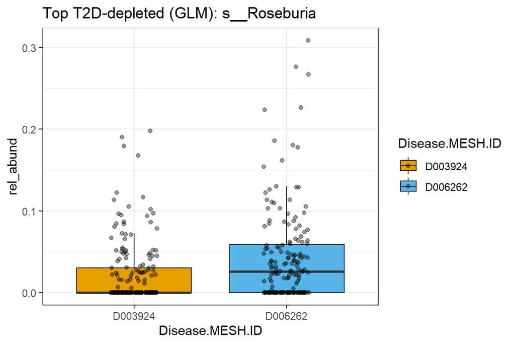

```r
top_taxon <- glm_T2D_depleted %>% slice(1) %>% pull(taxon)
top_label <- glm_T2D_depleted %>% slice(1) %>% pull(Species)

dat_rel %>%
  filter(taxon == top_taxon) %>%
  ggplot(aes(x = Disease.MESH.ID, y = rel_abund, fill = Disease.MESH.ID)) +
    geom_boxplot(outlier.shape = NA) +
    geom_jitter(width = 0.15, alpha = 0.4) +
    scale_fill_manual(values = c("D003924" = "#E69F00", "D006262" = "#56B4E9")) +
    theme_bw() +
    labs(title = paste("Top T2D-depleted (GLM):", top_label))
```

> *Taught in: W21 reference Rmd §6 (raw boxplot of the top GLM hit as a visual sanity check).*

### Top T2D-enriched (GLM)

```r
glm_T2D_enriched <- glm_disease_results %>%
  select(taxon, Genus, Species, estimate, fold_change_T2D_vs_Healthy,
         std.error, statistic, p.value, q_value) %>%
  arrange(-fold_change_T2D_vs_Healthy) %>%
  head(10)

glm_T2D_enriched
```

```
## # A tibble: 10 × 9
##    taxon  Genus      Species estimate fold_change_T2D_vs_H…¹ std.error statistic
##    <chr>  <chr>      <chr>      <dbl>                  <dbl>     <dbl>     <dbl>
##  1 1678   g__Bifido… s__Bif…    0.662                   4.59    0.228       2.91
##  2 906    g__Veillo… s__Meg…    0.618                   4.15    0.157       3.95
##  3 1578   g__Lactob… s__Lac…    0.528                   3.37    0.126       4.20
##  4 375288 g__Bacter… s__Tan…    0.435                   2.72    0.231       1.89
##  5 239934 g__Akkerm… s__Akk…    0.386                   2.43    0.134       2.87
##  6 904    g__Acidam… s__Aci…    0.252                   1.79    0.0960      2.62
##  7 292632 g__Rumino… s__Sub…    0.238                   1.73    0.236       1.01
##  8 100883 g__Erysip… s__Cop…    0.218                   1.65    0.0952      2.29
##  9 29465  g__Veillo… s__Vei…    0.186                   1.53    0.132       1.40
## 10 102106 g__Coriob… s__Col…    0.168                   1.47    0.0860      1.96
## # ℹ abbreviated name: ¹fold_change_T2D_vs_Healthy
## # ℹ 2 more variables: p.value <dbl>, q_value <dbl>
```

> *Taught in: W21 reference Rmd §6 (top table ordered by fold change, enriched tail).*

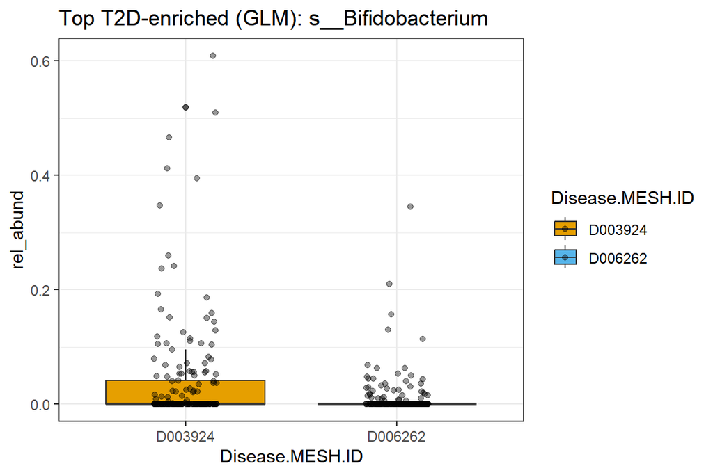

```r
top_taxon <- glm_T2D_enriched %>% slice(1) %>% pull(taxon)
top_label <- glm_T2D_enriched %>% slice(1) %>% pull(Species)

dat_rel %>%
  filter(taxon == top_taxon) %>%
  ggplot(aes(x = Disease.MESH.ID, y = rel_abund, fill = Disease.MESH.ID)) +
    geom_boxplot(outlier.shape = NA) +
    geom_jitter(width = 0.15, alpha = 0.4) +
    scale_fill_manual(values = c("D003924" = "#E69F00", "D006262" = "#56B4E9")) +
    theme_bw() +
    labs(title = paste("Top T2D-enriched (GLM):", top_label))
```

> *Taught in: W21 reference Rmd §6 (raw boxplot of the top enriched GLM hit).*

### Volcano plot — GLM (unadjusted)

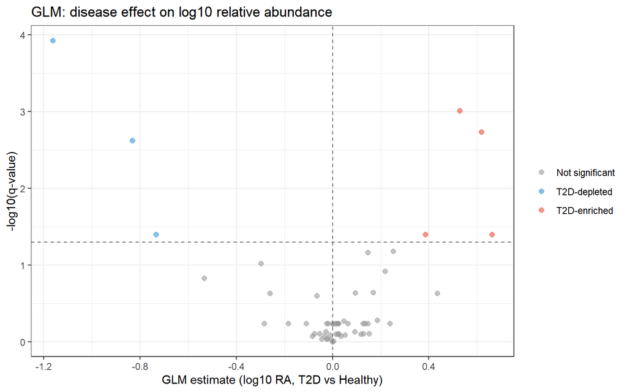

```r
glm_disease_results %>%
  mutate(
    neg_log10_q = -log10(q_value),
    direction = case_when(
      q_value < 0.05 & estimate > 0 ~ "T2D-enriched",
      q_value < 0.05 & estimate < 0 ~ "T2D-depleted",
      TRUE                          ~ "Not significant"
    )
  ) %>%
  ggplot(aes(x = estimate, y = neg_log10_q, color = direction)) +
    geom_point(alpha = 0.6, size = 2) +
    scale_color_manual(values = c("T2D-enriched" = "#E74C3C",
                                  "T2D-depleted" = "#3498DB",
                                  "Not significant" = "grey60")) +
    geom_hline(yintercept = -log10(0.05), linetype = "dashed", color = "grey40") +
    geom_vline(xintercept = 0, linetype = "dashed", color = "grey40") +
    labs(x = "GLM estimate (log10 RA, T2D vs Healthy)",
         y = "-log10(q-value)", color = NULL,
         title = "GLM: disease effect on log10 relative abundance") +
    theme_bw()
```

> *Taught in: W21 reference Rmd §6 (GLM volcano plot using the model estimate as the effect-size axis).*

### Bar chart — GLM top hits

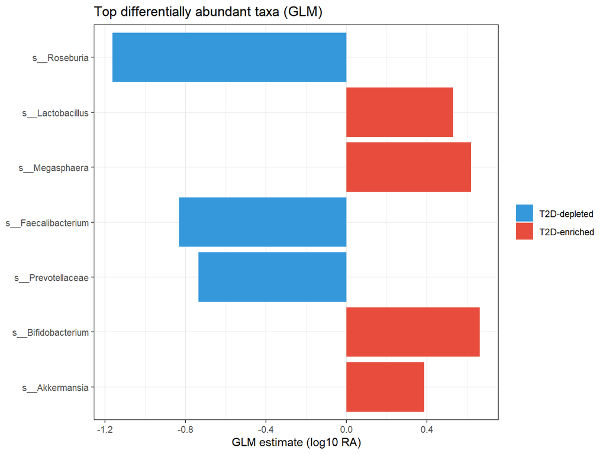

```r
bind_rows(
  glm_disease_results %>% filter(q_value < 0.05) %>% arrange(estimate)  %>% head(10),
  glm_disease_results %>% filter(q_value < 0.05) %>% arrange(-estimate) %>% head(10)
) %>%
  distinct() %>%
  mutate(
    label = Species,
    direction = ifelse(estimate > 0, "T2D-enriched", "T2D-depleted")
  ) %>%
  ggplot(aes(x = reorder(label, -q_value), y = estimate, fill = direction)) +
    geom_col() +
    coord_flip() +
    scale_fill_manual(values = c("T2D-enriched" = "#E74C3C", "T2D-depleted" = "#3498DB")) +
    labs(x = NULL, y = "GLM estimate (log10 RA)", fill = NULL,
         title = "Top differentially abundant taxa (GLM)") +
    theme_bw()
```

> *Taught in: W21 reference Rmd §6 (bar chart of top significant GLM taxa ordered by q-value).*

## Primary adjusted model — Sex + Host.age (n = 359)

Sex and Host.age have no missing values in this cohort, so both are added to the primary model without losing samples. Recent.antibiotics.use is monomorphic in this cohort (all participants screened out at enrolment), so it is not included. BMI is missing for 58% of samples and is handled as a sensitivity analysis later.

```r
glm_disease_adjusted_sex_results <- dat_rel %>%
  mutate(
    Disease.MESH.ID = factor(Disease.MESH.ID, levels = c("D006262", "D003924")),
    Sex             = factor(Sex,             levels = c("Female", "Male")),
    Host.age        = as.numeric(Host.age)
  ) %>%
  group_by(taxon, Genus, Species) %>%
  group_modify(~ {
    fit <- glm(log10(rel_abund + 1e-6) ~ Disease.MESH.ID + Sex + Host.age,
               data = .x, family = gaussian())
    broom::tidy(fit)
  }) %>%
  ungroup() %>%
  filter(term == "Disease.MESH.IDD003924") %>%
  mutate(
    q_value = p.adjust(p.value, method = "BH"),
    fold_change_T2D_vs_Healthy_adj = 10^estimate
  )
```

> *Taught in: W21 reference Rmd §7 “Adjust the linear model for health status” (add a covariate, keep the retained group term). The teacher adjusts for `status`; here the primary covariates are `Sex` + `Host.age`. Covariate adjustment in linear models: Alberdi reading §5. Sex/Age chosen because they are the only complete, polymorphic metadata variables (antibiotics monomorphic; BMI 58% missing → §“Sensitivity analysis” below).*

### Top T2D-depleted (GLM adjusted for Sex + Age)

```r
glm_adj_T2D_depleted <- glm_disease_adjusted_sex_results %>%
  select(taxon, Genus, Species, estimate, fold_change_T2D_vs_Healthy_adj,
         std.error, statistic, p.value, q_value) %>%
  arrange(fold_change_T2D_vs_Healthy_adj) %>%
  head(10)

glm_adj_T2D_depleted
```

```
## # A tibble: 10 × 9
##    taxon  Genus      Species estimate fold_change_T2D_vs_H…¹ std.error statistic
##    <chr>  <chr>      <chr>      <dbl>                  <dbl>     <dbl>     <dbl>
##  1 841    g__Lachno… s__Ros…  -1.01                   0.0983     0.261    -3.85
##  2 216851 g__Rumino… s__Fae…  -0.827                  0.149      0.239    -3.46
##  3 838    g__Bacter… s__Pre…  -0.593                  0.256      0.280    -2.11
##  4 1730   g__Eubact… s__Eub…  -0.514                  0.306      0.269    -1.91
##  5 724    g__Haemop… s__      -0.316                  0.483      0.135    -2.35
##  6 33042  g__Lachno… s__Cop…  -0.271                  0.536      0.154    -1.76
##  7 570    g__Klebsi… s__      -0.215                  0.610      0.182    -1.18
##  8 1263   g__Rumino… s__Rum…  -0.173                  0.672      0.269    -0.640
##  9 572511 g__Lachno… s__Bla…  -0.101                  0.792      0.260    -0.390
## 10 189330 g__Lachno… s__Dor…  -0.0933                 0.807      0.127    -0.733
## # ℹ abbreviated name: ¹fold_change_T2D_vs_Healthy_adj
## # ℹ 2 more variables: p.value <dbl>, q_value <dbl>
```

> *Taught in: W21 reference Rmd §7 (adjusted top table, depleted tail).*

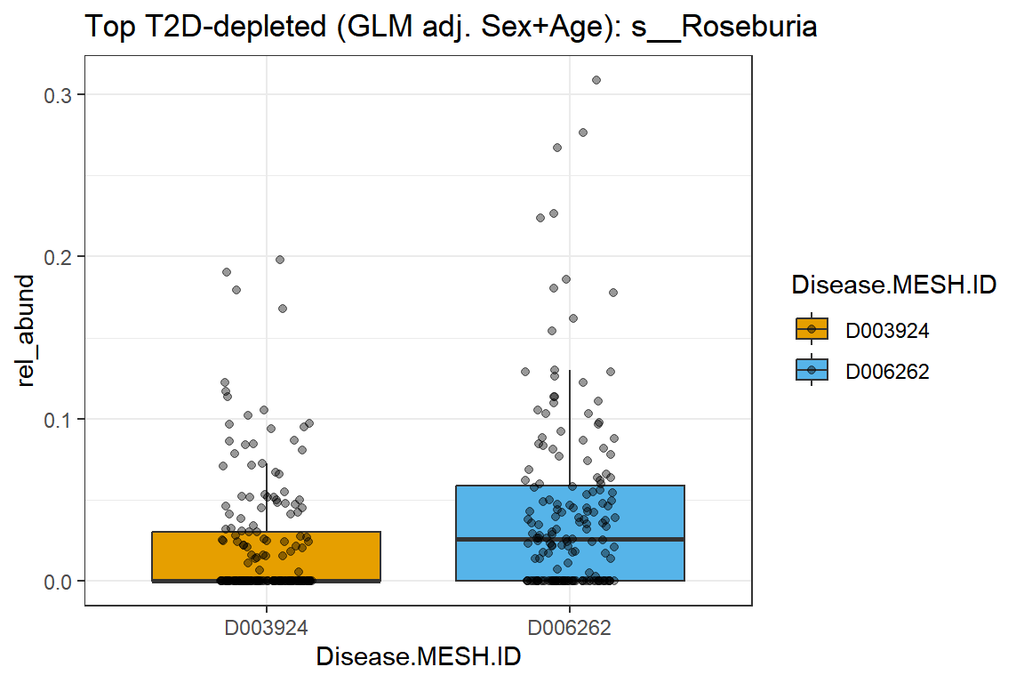

```r
top_taxon <- glm_adj_T2D_depleted %>% slice(1) %>% pull(taxon)
top_label <- glm_adj_T2D_depleted %>% slice(1) %>% pull(Species)

dat_rel %>%
  filter(taxon == top_taxon) %>%
  ggplot(aes(x = Disease.MESH.ID, y = rel_abund, fill = Disease.MESH.ID)) +
    geom_boxplot(outlier.shape = NA) +
    geom_jitter(width = 0.15, alpha = 0.4) +
    scale_fill_manual(values = c("D003924" = "#E69F00", "D006262" = "#56B4E9")) +
    theme_bw() +
    labs(title = paste("Top T2D-depleted (GLM adj. Sex+Age):", top_label))
```

> *Taught in: W21 reference Rmd §7 (raw boxplot of top adjusted hit — note this plot is marginal over the covariates, so it is a visual check, not the adjusted estimate).*

### Top T2D-enriched (GLM adjusted for Sex + Age)

```r
glm_adj_T2D_enriched <- glm_disease_adjusted_sex_results %>%
  select(taxon, Genus, Species, estimate, fold_change_T2D_vs_Healthy_adj,
         std.error, statistic, p.value, q_value) %>%
  arrange(-fold_change_T2D_vs_Healthy_adj) %>%
  head(10)

glm_adj_T2D_enriched
```

```
## # A tibble: 10 × 9
##    taxon  Genus      Species estimate fold_change_T2D_vs_H…¹ std.error statistic
##    <chr>  <chr>      <chr>      <dbl>                  <dbl>     <dbl>     <dbl>
##  1 375288 g__Bacter… s__Tan…    0.657                   4.54     0.250     2.63
##  2 906    g__Veillo… s__Meg…    0.562                   3.65     0.171     3.29
##  3 1678   g__Bifido… s__Bif…    0.452                   2.83     0.246     1.83
##  4 1578   g__Lactob… s__Lac…    0.408                   2.56     0.136     3.00
##  5 239934 g__Akkerm… s__Akk…    0.340                   2.19     0.147     2.32
##  6 397864 g__Bacter… s__Bar…    0.300                   1.99     0.128     2.33
##  7 292632 g__Rumino… s__Sub…    0.254                   1.79     0.256     0.989
##  8 100883 g__Erysip… s__Cop…    0.239                   1.73     0.104     2.29
##  9 904    g__Acidam… s__Aci…    0.188                   1.54     0.105     1.79
## 10 848    g__Fusoba… s__        0.176                   1.50     0.154     1.15
## # ℹ abbreviated name: ¹fold_change_T2D_vs_Healthy_adj
## # ℹ 2 more variables: p.value <dbl>, q_value <dbl>
```

> *Taught in: W21 reference Rmd §7 (adjusted top table, enriched tail).*

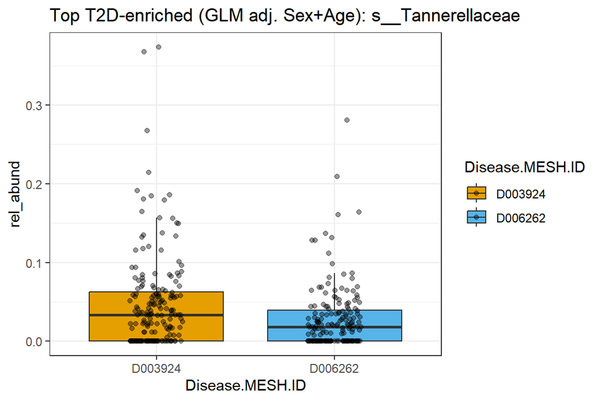

```r
top_taxon <- glm_adj_T2D_enriched %>% slice(1) %>% pull(taxon)
top_label <- glm_adj_T2D_enriched %>% slice(1) %>% pull(Species)

dat_rel %>%
  filter(taxon == top_taxon) %>%
  ggplot(aes(x = Disease.MESH.ID, y = rel_abund, fill = Disease.MESH.ID)) +
    geom_boxplot(outlier.shape = NA) +
    geom_jitter(width = 0.15, alpha = 0.4) +
    scale_fill_manual(values = c("D003924" = "#E69F00", "D006262" = "#56B4E9")) +
    theme_bw() +
    labs(title = paste("Top T2D-enriched (GLM adj. Sex+Age):", top_label))
```

> *Taught in: W21 reference Rmd §7 (raw boxplot of top enriched adjusted hit).*

### Volcano plot — GLM adjusted for Sex + Age

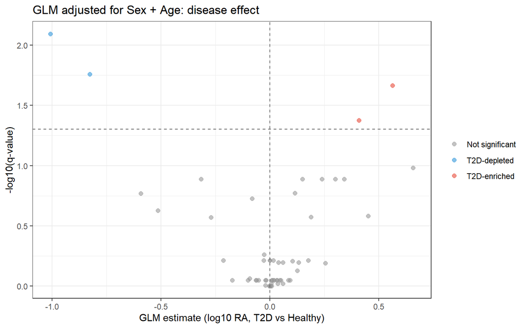

```r
glm_disease_adjusted_sex_results %>%
  mutate(
    neg_log10_q = -log10(q_value),
    direction = case_when(
      q_value < 0.05 & estimate > 0 ~ "T2D-enriched",
      q_value < 0.05 & estimate < 0 ~ "T2D-depleted",
      TRUE                          ~ "Not significant"
    )
  ) %>%
  ggplot(aes(x = estimate, y = neg_log10_q, color = direction)) +
    geom_point(alpha = 0.6, size = 2) +
    scale_color_manual(values = c("T2D-enriched" = "#E74C3C",
                                  "T2D-depleted" = "#3498DB",
                                  "Not significant" = "grey60")) +
    geom_hline(yintercept = -log10(0.05), linetype = "dashed", color = "grey40") +
    geom_vline(xintercept = 0, linetype = "dashed", color = "grey40") +
    labs(x = "GLM estimate (log10 RA, T2D vs Healthy)",
         y = "-log10(q-value)", color = NULL,
         title = "GLM adjusted for Sex + Age: disease effect") +
    theme_bw()
```

> *Taught in: W21 reference Rmd §7 (adjusted-model volcano plot).*

### Bar chart — GLM adjusted (Sex + Age) top hits

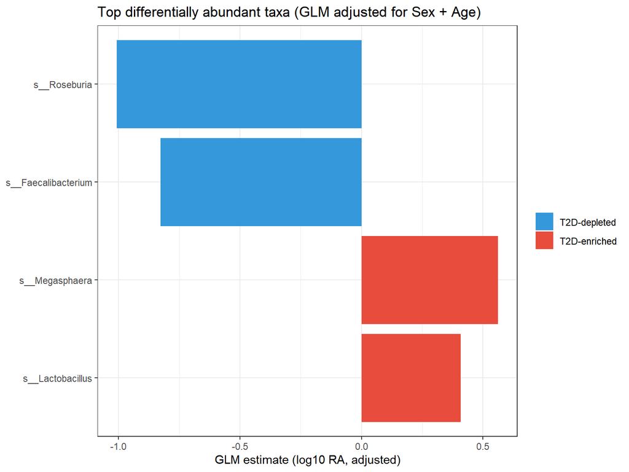

```r
bind_rows(
  glm_disease_adjusted_sex_results %>% filter(q_value < 0.05) %>% arrange(estimate)  %>% head(10),
  glm_disease_adjusted_sex_results %>% filter(q_value < 0.05) %>% arrange(-estimate) %>% head(10)
) %>%
  distinct() %>%
  mutate(
    label = Species,
    direction = ifelse(estimate > 0, "T2D-enriched", "T2D-depleted")
  ) %>%
  ggplot(aes(x = reorder(label, -q_value), y = estimate, fill = direction)) +
    geom_col() +
    coord_flip() +
    scale_fill_manual(values = c("T2D-enriched" = "#E74C3C", "T2D-depleted" = "#3498DB")) +
    labs(x = NULL, y = "GLM estimate (log10 RA, adjusted)", fill = NULL,
         title = "Top differentially abundant taxa (GLM adjusted for Sex + Age)") +
    theme_bw()
```

> *Taught in: W21 reference Rmd §7 (bar chart of top adjusted significant taxa ordered by q-value).*

## Compositional analysis with CLR transformation

```r
ps_clr <- transform_sample_counts(ps, function(x) {
  x <- x + 1e-9
  log(x) - mean(log(x))
})
otu_clr  <- as(otu_table(ps_clr), "matrix") %>% t() %>% as.data.frame()
meta_clr <- data.frame(sample_data(ps_clr))
tax_clr  <- as(tax_table(ps_clr), "matrix") %>% as.data.frame()
```

> *Taught in: W21 reference Rmd §9 “Compositional analysis with CLR transformation” (the `transform_sample_counts` CLR closure: add pseudocount, `log(x) - mean(log(x))`). Why CLR for closed/relative-abundance data: Alberdi reading §7 (compositionality).*

```r
dat_clr <- otu_clr %>%
  rownames_to_column("sample_id") %>%
  pivot_longer(-sample_id, names_to = "taxon", values_to = "clr") %>%
  left_join(meta_clr %>% rownames_to_column("sample_id"), by = "sample_id") %>%
  left_join(tax_clr  %>% rownames_to_column("taxon"),     by = "taxon")
```

> *Taught in: W21 reference Rmd §9 (the hidden chunk that reshapes CLR values into the long `dat_clr` table).*

```r
clr_disease_adjusted_sex_results <- dat_clr %>%
  mutate(
    Disease.MESH.ID = factor(Disease.MESH.ID, levels = c("D006262", "D003924")),
    Sex             = factor(Sex,             levels = c("Female", "Male")),
    Host.age        = as.numeric(Host.age)
  ) %>%
  group_by(taxon, Genus, Species) %>%
  group_modify(~ {
    fit <- lm(clr ~ Disease.MESH.ID + Sex + Host.age, data = .x)
    broom::tidy(fit)
  }) %>%
  ungroup() %>%
  filter(term == "Disease.MESH.IDD003924") %>%
  mutate(q_value = p.adjust(p.value, method = "BH"))
```

> *Taught in: W21 reference Rmd §9 (`lm(clr ~ group + covariate)` per taxon, BH-adjusted). Teacher adjusts for `status`; here `Sex` + `Host.age`, matching the primary GLM. Compositional linear modelling: Alberdi reading §7.*

Positive CLR estimate = T2D-enriched relative to the community geometric mean.

### Top T2D-depleted (CLR)

```r
clr_T2D_depleted <- clr_disease_adjusted_sex_results %>%
  select(taxon, Genus, Species, estimate, std.error, statistic, p.value, q_value) %>%
  arrange(estimate) %>%
  head(10)

clr_T2D_depleted
```

```
## # A tibble: 10 × 8
##    taxon  Genus             Species estimate std.error statistic p.value q_value
##    <chr>  <chr>             <chr>      <dbl>     <dbl>     <dbl>   <dbl>   <dbl>
##  1 841    g__Lachnospirace… s__Ros…   -3.75      0.980    -3.83  1.51e-4 0.00878
##  2 216851 g__Ruminococcace… s__Fae…   -3.05      0.883    -3.46  6.12e-4 0.0177
##  3 838    g__Bacteroidales  s__Pre…   -2.03      0.994    -2.05  4.14e-2 0.185
##  4 1730   g__Eubacteriaceae s__Eub…   -1.95      0.989    -1.97  4.97e-2 0.206
##  5 724    g__Haemophilus    s__       -1.22      0.516    -2.37  1.84e-2 0.141
##  6 33042  g__Lachnospirace… s__Cop…   -1.05      0.585    -1.80  7.30e-2 0.282
##  7 570    g__Klebsiella     s__       -0.852     0.685    -1.24  2.15e-1 0.567
##  8 1263   g__Ruminococcace… s__Rum…   -0.743     1.01     -0.737 4.62e-1 0.847
##  9 572511 g__Lachnospirace… s__Bla…   -0.475     0.988    -0.480 6.31e-1 0.952
## 10 544    g__Citrobacter    s__       -0.350     0.164    -2.13  3.37e-2 0.178
```

> *Taught in: W21 reference Rmd §9 (CLR top table, depleted tail).*

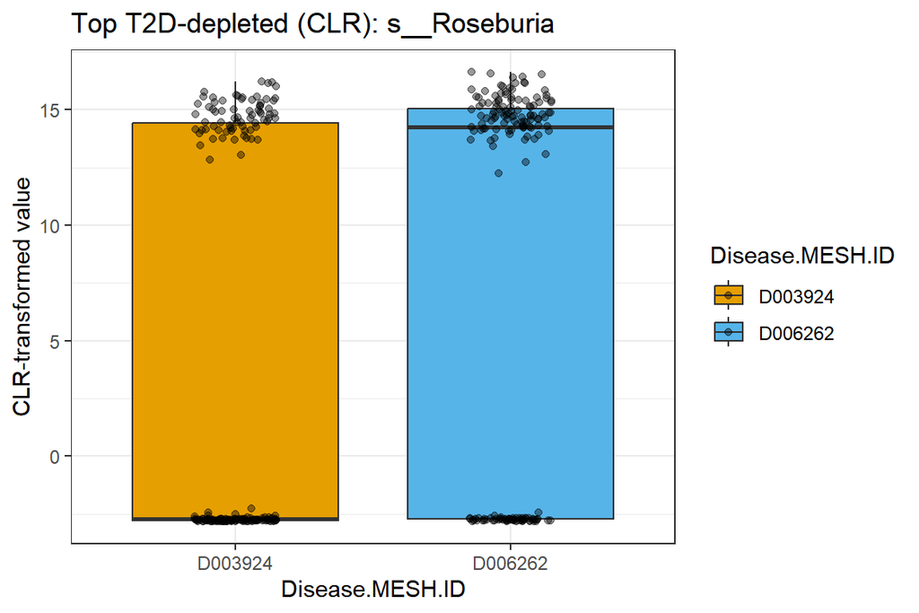

```r
top_taxon <- clr_T2D_depleted %>% slice(1) %>% pull(taxon)
top_label <- clr_T2D_depleted %>% slice(1) %>% pull(Species)

dat_clr %>%
  filter(taxon == top_taxon) %>%
  ggplot(aes(x = Disease.MESH.ID, y = clr, fill = Disease.MESH.ID)) +
    geom_boxplot(outlier.shape = NA) +
    geom_jitter(width = 0.15, alpha = 0.4) +
    scale_fill_manual(values = c("D003924" = "#E69F00", "D006262" = "#56B4E9")) +
    theme_bw() +
    labs(title = paste("Top T2D-depleted (CLR):", top_label),
         y = "CLR-transformed value")
```

> *Taught in: W21 reference Rmd §9 (boxplot of the top CLR hit on the CLR scale — compare direction, not raw magnitude).*

### Top T2D-enriched (CLR)

```r
clr_T2D_enriched <- clr_disease_adjusted_sex_results %>%
  select(taxon, Genus, Species, estimate, std.error, statistic, p.value, q_value) %>%
  arrange(-estimate) %>%
  head(10)

clr_T2D_enriched
```

```
## # A tibble: 10 × 8
##    taxon  Genus             Species estimate std.error statistic p.value q_value
##    <chr>  <chr>             <chr>      <dbl>     <dbl>     <dbl>   <dbl>   <dbl>
##  1 375288 g__Bacteroidales  s__Tan…    2.36      0.940     2.51  0.0124   0.141
##  2 906    g__Veillonellace… s__Meg…    2.08      0.643     3.23  0.00137  0.0264
##  3 1678   g__Bifidobacteri… s__Bif…    1.54      0.922     1.67  0.0957   0.292
##  4 1578   g__Lactobacillac… s__Lac…    1.51      0.506     2.97  0.00315  0.0456
##  5 239934 g__Akkermansiace… s__Akk…    1.24      0.540     2.29  0.0228   0.141
##  6 397864 g__Bacteroidales  s__Bar…    1.14      0.493     2.32  0.0210   0.141
##  7 100883 g__Erysipelotric… s__Cop…    0.931     0.412     2.26  0.0244   0.141
##  8 292632 g__Ruminococcace… s__Sub…    0.864     0.969     0.892 0.373    0.746
##  9 904    g__Acidaminococc… s__Aci…    0.674     0.390     1.73  0.0846   0.287
## 10 848    g__Fusobacterium  s__        0.631     0.592     1.07  0.287    0.694
```

> *Taught in: W21 reference Rmd §9 (CLR top table, enriched tail).*

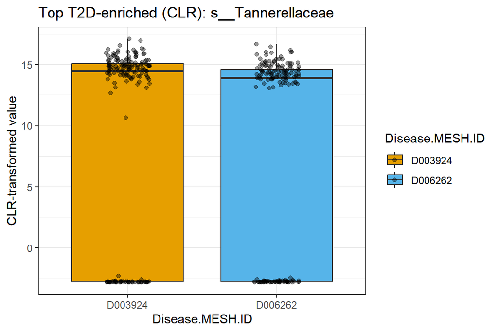

```r
top_taxon <- clr_T2D_enriched %>% slice(1) %>% pull(taxon)
top_label <- clr_T2D_enriched %>% slice(1) %>% pull(Species)

dat_clr %>%
  filter(taxon == top_taxon) %>%
  ggplot(aes(x = Disease.MESH.ID, y = clr, fill = Disease.MESH.ID)) +
    geom_boxplot(outlier.shape = NA) +
    geom_jitter(width = 0.15, alpha = 0.4) +
    scale_fill_manual(values = c("D003924" = "#E69F00", "D006262" = "#56B4E9")) +
    theme_bw() +
    labs(title = paste("Top T2D-enriched (CLR):", top_label),
         y = "CLR-transformed value")
```

> *Taught in: W21 reference Rmd §9 (boxplot of the top enriched CLR hit on the CLR scale).*

### Volcano plot — CLR

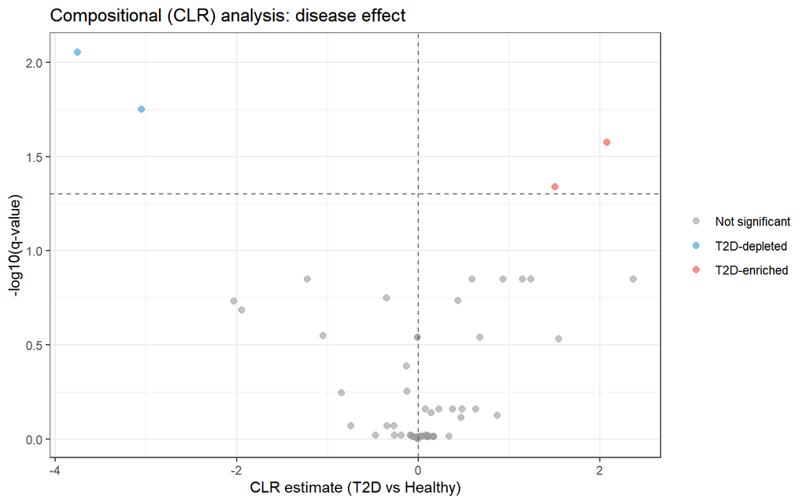

```r
clr_disease_adjusted_sex_results %>%
  mutate(
    neg_log10_q = -log10(q_value),
    direction = case_when(
      q_value < 0.05 & estimate > 0 ~ "T2D-enriched",
      q_value < 0.05 & estimate < 0 ~ "T2D-depleted",
      TRUE                          ~ "Not significant"
    )
  ) %>%
  ggplot(aes(x = estimate, y = neg_log10_q, color = direction)) +
    geom_point(alpha = 0.6, size = 2) +
    scale_color_manual(values = c("T2D-enriched" = "#E74C3C",
                                  "T2D-depleted" = "#3498DB",
                                  "Not significant" = "grey60")) +
    geom_hline(yintercept = -log10(0.05), linetype = "dashed", color = "grey40") +
    geom_vline(xintercept = 0, linetype = "dashed", color = "grey40") +
    labs(x = "CLR estimate (T2D vs Healthy)",
         y = "-log10(q-value)", color = NULL,
         title = "Compositional (CLR) analysis: disease effect") +
    theme_bw()
```

> *Taught in: W21 reference Rmd §9 (CLR volcano plot — the compositionally aware reference analysis).*

### Bar chart — CLR top hits

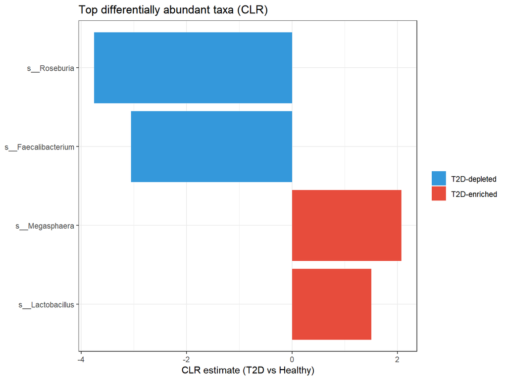

```r
bind_rows(
  clr_disease_adjusted_sex_results %>% filter(q_value < 0.05) %>% arrange(estimate)  %>% head(10),
  clr_disease_adjusted_sex_results %>% filter(q_value < 0.05) %>% arrange(-estimate) %>% head(10)
) %>%
  distinct() %>%
  mutate(
    label = Species,
    direction = ifelse(estimate > 0, "T2D-enriched", "T2D-depleted")
  ) %>%
  ggplot(aes(x = reorder(label, -q_value), y = estimate, fill = direction)) +
    geom_col() +
    coord_flip() +
    scale_fill_manual(values = c("T2D-enriched" = "#E74C3C", "T2D-depleted" = "#3498DB")) +
    labs(x = NULL, y = "CLR estimate (T2D vs Healthy)", fill = NULL,
         title = "Top differentially abundant taxa (CLR)") +
    theme_bw()
```

> *Taught in: W21 reference Rmd §9 (bar chart of top CLR significant taxa ordered by q-value).*

## Sensitivity analysis — adding BMI (n = 151)

BMI is missing for 58% of the cohort (208 of 359 samples). Including it in the primary model would drop more than half the data and risk missing-not-at-random bias. We therefore run a sensitivity analysis restricted to the 151 samples with complete BMI: if the disease effect estimates broadly agree with the primary model, the BMI confound is unlikely to be driving the findings; if they disagree substantially, BMI-driven confounding must be discussed explicitly in the report.

```r
meta_check <- data.frame(sample_data(ps))
sensitivity_n <- meta_check %>%
  filter(!is.na(BMI), !is.na(Host.age), !is.na(Sex)) %>%
  nrow()
sensitivity_n
```

```
## [1] 151
```

> *Project-chosen step (not a separate taught method): counts samples with complete covariates, the standard precondition for a complete-case covariate model (W21 §7 fits on complete data). Listed here to justify the n = 151 sensitivity sample.*

### GLM sensitivity — Sex + Host.age + BMI

```r
glm_disease_sensitivity_BMI <- dat_rel %>%
  mutate(
    Disease.MESH.ID = factor(Disease.MESH.ID, levels = c("D006262", "D003924")),
    Sex             = factor(Sex,             levels = c("Female", "Male")),
    Host.age        = as.numeric(Host.age),
    BMI             = as.numeric(BMI)
  ) %>%
  filter(!is.na(BMI)) %>%
  group_by(taxon, Genus, Species) %>%
  group_modify(~ {
    fit <- glm(log10(rel_abund + 1e-6) ~ Disease.MESH.ID + Sex + Host.age + BMI,
               data = .x, family = gaussian())
    broom::tidy(fit)
  }) %>%
  ungroup() %>%
  filter(term == "Disease.MESH.IDD003924") %>%
  mutate(
    q_value = p.adjust(p.value, method = "BH"),
    fold_change_T2D_vs_Healthy_BMI = 10^estimate
  )

# Top T2D-depleted with BMI adjustment
glm_disease_sensitivity_BMI %>%
  select(taxon, Genus, Species, estimate, fold_change_T2D_vs_Healthy_BMI,
         std.error, statistic, p.value, q_value) %>%
  arrange(fold_change_T2D_vs_Healthy_BMI) %>%
  head(10)
```

```
## # A tibble: 10 × 9
##    taxon  Genus      Species estimate fold_change_T2D_vs_H…¹ std.error statistic
##    <chr>  <chr>      <chr>      <dbl>                  <dbl>     <dbl>     <dbl>
##  1 841    g__Lachno… s__Ros…   -1.09                  0.0822     0.470    -2.31
##  2 1485   g__Clostr… s__Clo…   -1.01                  0.0974     0.456    -2.22
##  3 216851 g__Rumino… s__Fae…   -0.818                 0.152      0.433    -1.89
##  4 724    g__Haemop… s__       -0.647                 0.226      0.241    -2.69
##  5 1263   g__Rumino… s__Rum…   -0.565                 0.272      0.487    -1.16
##  6 283168 g__Bacter… s__Odo…   -0.278                 0.528      0.295    -0.942
##  7 561    g__Escher… s__       -0.266                 0.542      0.501    -0.531
##  8 572511 g__Lachno… s__Bla…   -0.235                 0.582      0.481    -0.489
##  9 29465  g__Veillo… s__Vei…   -0.179                 0.663      0.283    -0.631
## 10 816    g__Bacter… s__Bac…   -0.124                 0.751      0.186    -0.667
## # ℹ abbreviated name: ¹fold_change_T2D_vs_Healthy_BMI
## # ℹ 2 more variables: p.value <dbl>, q_value <dbl>
```

> *Method taught in: W21 reference Rmd §7 (covariate-adjusted GLM) — identical model, with BMI added as an extra covariate. BMI is a **project-chosen** covariate, not one used in the reference; it is run only as a sensitivity check because it is missing for 58% of samples (so it is not in the primary model).*

### CLR sensitivity — Sex + Host.age + BMI

```r
clr_disease_sensitivity_BMI <- dat_clr %>%
  mutate(
    Disease.MESH.ID = factor(Disease.MESH.ID, levels = c("D006262", "D003924")),
    Sex             = factor(Sex,             levels = c("Female", "Male")),
    Host.age        = as.numeric(Host.age),
    BMI             = as.numeric(BMI)
  ) %>%
  filter(!is.na(BMI)) %>%
  group_by(taxon, Genus, Species) %>%
  group_modify(~ {
    fit <- lm(clr ~ Disease.MESH.ID + Sex + Host.age + BMI, data = .x)
    broom::tidy(fit)
  }) %>%
  ungroup() %>%
  filter(term == "Disease.MESH.IDD003924") %>%
  mutate(q_value = p.adjust(p.value, method = "BH"))

clr_disease_sensitivity_BMI %>%
  select(taxon, Genus, Species, estimate, std.error, statistic, p.value, q_value) %>%
  arrange(estimate) %>%
  head(10)
```

```
## # A tibble: 10 × 8
##    taxon  Genus             Species estimate std.error statistic p.value q_value
##    <chr>  <chr>             <chr>      <dbl>     <dbl>     <dbl>   <dbl>   <dbl>
##  1 841    g__Lachnospirace… s__Ros…   -3.96      1.78     -2.23  0.0273    0.395
##  2 1485   g__Clostridiaceae s__Clo…   -3.94      1.73     -2.27  0.0244    0.395
##  3 216851 g__Ruminococcace… s__Fae…   -2.95      1.60     -1.84  0.0672    0.754
##  4 724    g__Haemophilus    s__       -2.45      0.927    -2.64  0.00921   0.395
##  5 1263   g__Ruminococcace… s__Rum…   -2.25      1.83     -1.23  0.220     0.754
##  6 561    g__Escherichia    s__       -1.14      1.88     -0.607 0.545     0.771
##  7 283168 g__Bacteroidales  s__Odo…   -1.08      1.14     -0.952 0.343     0.754
##  8 572511 g__Lachnospirace… s__Bla…   -0.912     1.83     -0.497 0.620     0.817
##  9 29465  g__Veillonellace… s__Vei…   -0.789     1.09     -0.723 0.471     0.754
## 10 292632 g__Ruminococcace… s__Sub…   -0.505     1.76     -0.287 0.774     0.904
```

> *Method taught in: W21 reference Rmd §9 (covariate-adjusted CLR linear model) — identical model with BMI added. As above, BMI is a **project-chosen** sensitivity covariate, not part of the reference.*

### Primary vs BMI-sensitivity scatter (CLR)

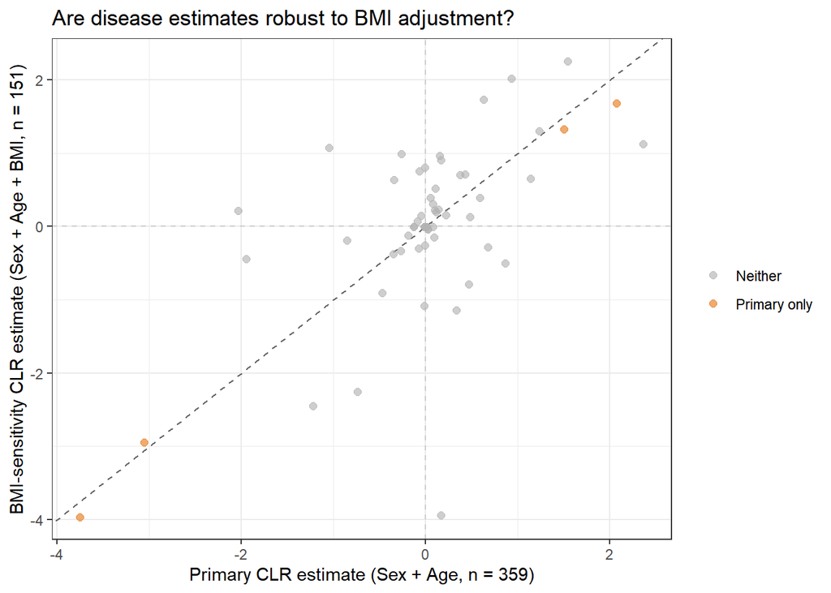

```r
clr_disease_adjusted_sex_results %>%
  select(taxon, primary_estimate = estimate, primary_q = q_value) %>%
  inner_join(
    clr_disease_sensitivity_BMI %>%
      select(taxon, BMI_estimate = estimate, BMI_q = q_value),
    by = "taxon"
  ) %>%
  mutate(
    category = case_when(
      primary_q < 0.05 & BMI_q < 0.05 ~ "Significant in both",
      primary_q < 0.05               ~ "Primary only",
      BMI_q < 0.05                   ~ "BMI-sensitivity only",
      TRUE                           ~ "Neither"
    )
  ) %>%
  ggplot(aes(x = primary_estimate, y = BMI_estimate, color = category)) +
    geom_abline(slope = 1, intercept = 0, linetype = "dashed", color = "grey40") +
    geom_hline(yintercept = 0, linetype = "dashed", color = "grey80") +
    geom_vline(xintercept = 0, linetype = "dashed", color = "grey80") +
    geom_point(alpha = 0.65, size = 2) +
    scale_color_manual(values = c(
      "Significant in both"   = "#2E8B57",
      "Primary only"          = "#E67E22",
      "BMI-sensitivity only"  = "#3498DB",
      "Neither"               = "grey70"
    )) +
    labs(x = "Primary CLR estimate (Sex + Age, n = 359)",
         y = "BMI-sensitivity CLR estimate (Sex + Age + BMI, n = 151)",
         color = NULL,
         title = "Are disease estimates robust to BMI adjustment?") +
    theme_bw()
```

> *Plot technique taught in: W21 reference Rmd §10 (effect-size scatter comparing two models against the identity line — the reference uses it for “GLM unadjusted vs adjusted for status”). Here the same technique compares the primary model with the BMI-sensitivity model; the comparison itself is a project-chosen application.*

Points near the dashed identity line are robust to BMI adjustment. Points well off the line are taxa whose apparent disease effect partly reflects BMI.

## Compare differential abundance methods

```r
comparison_results <- wilcox_results %>%
  select(taxon, Genus, Species,
         wilcox_log2fc = log2_fc,
         wilcox_q = q_value) %>%
  left_join(
    glm_disease_results %>%
      select(taxon, glm_estimate = estimate, glm_q = q_value),
    by = "taxon"
  ) %>%
  left_join(
    glm_disease_adjusted_sex_results %>%
      select(taxon, glm_adj_estimate = estimate, glm_adj_q = q_value),
    by = "taxon"
  ) %>%
  left_join(
    clr_disease_adjusted_sex_results %>%
      select(taxon, clr_estimate = estimate, clr_q = q_value),
    by = "taxon"
  )
```

> *Taught in: W21 reference Rmd §10 “Compare differential abundance methods” (the hidden chunk that joins effect estimates and q-values from all methods into `comparison_results`).*

### Significant taxa per method

```r
sig_summary <- tibble(
  method = c(
    "Wilcoxon (n=359)",
    "GLM unadjusted (n=359)",
    "GLM adj. Sex+Age (n=359)",
    "GLM adj. Sex+Age+BMI (n=151)",
    "CLR adj. Sex+Age (n=359)",
    "CLR adj. Sex+Age+BMI (n=151)"
  ),
  n_significant = c(
    sum(wilcox_results$q_value < 0.05, na.rm = TRUE),
    sum(glm_disease_results$q_value < 0.05, na.rm = TRUE),
    sum(glm_disease_adjusted_sex_results$q_value < 0.05, na.rm = TRUE),
    sum(glm_disease_sensitivity_BMI$q_value < 0.05, na.rm = TRUE),
    sum(clr_disease_adjusted_sex_results$q_value < 0.05, na.rm = TRUE),
    sum(clr_disease_sensitivity_BMI$q_value < 0.05, na.rm = TRUE)
  )
)

sig_summary
```

```
## # A tibble: 6 × 2
##   method                       n_significant
##   <chr>                                <int>
## 1 Wilcoxon (n=359)                         8
## 2 GLM unadjusted (n=359)                   7
## 3 GLM adj. Sex+Age (n=359)                 4
## 4 GLM adj. Sex+Age+BMI (n=151)             0
## 5 CLR adj. Sex+Age (n=359)                 4
## 6 CLR adj. Sex+Age+BMI (n=151)             0
```

> *Taught in: W21 reference Rmd §10 (count of significant taxa per method at q < 0.05). The reference has 4 rows (Wilcoxon, GLM, GLM adjusted, CLR); the two extra BMI-sensitivity rows are project additions reporting the same `sum(q < 0.05)` count for the sensitivity models.*

### Taxa significant in all four methods

```r
all_methods_sig <- comparison_results %>%
  filter(wilcox_q < 0.05, glm_q < 0.05, glm_adj_q < 0.05, clr_q < 0.05) %>%
  select(Genus, Species, wilcox_q, glm_q, glm_adj_q, clr_q) %>%
  arrange(wilcox_q)

all_methods_sig
```

```
## # A tibble: 4 × 6
##   Genus               Species             wilcox_q    glm_q glm_adj_q   clr_q
##   <chr>               <chr>                  <dbl>    <dbl>     <dbl>   <dbl>
## 1 g__Lachnospiraceae  s__Roseburia        0.000186 0.000118   0.00804 0.00878
## 2 g__Lactobacillaceae s__Lactobacillus    0.000992 0.000973   0.0422  0.0456
## 3 g__Ruminococcaceae  s__Faecalibacterium 0.00153  0.00237    0.0174  0.0177
## 4 g__Veillonellaceae  s__Megasphaera      0.00159  0.00185    0.0216  0.0264
```

> *Taught in: W21 reference Rmd §10 (taxa significant in all four methods = the consensus candidates).*

### GLM unadjusted vs adjusted for Sex

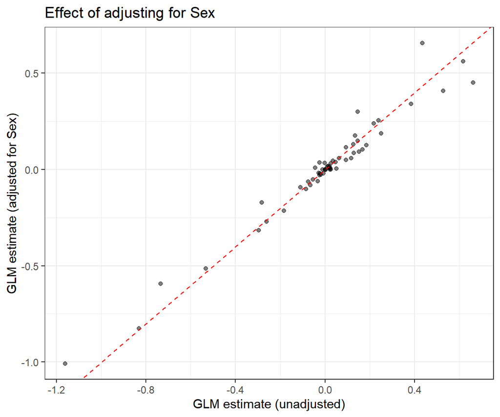

```r
comparison_results %>%
  ggplot(aes(x = glm_estimate, y = glm_adj_estimate)) +
    geom_point(alpha = 0.5) +
    geom_abline(slope = 1, intercept = 0, linetype = "dashed", color = "red") +
    labs(x = "GLM estimate (unadjusted)",
         y = "GLM estimate (adjusted for Sex)",
         title = "Effect of adjusting for Sex") +
    theme_bw()
```

> *Taught in: W21 reference Rmd §10 (scatter of unadjusted vs adjusted GLM estimates against the identity line — the reference adjusts for status, here for Sex + Age).*

### GLM adjusted vs CLR

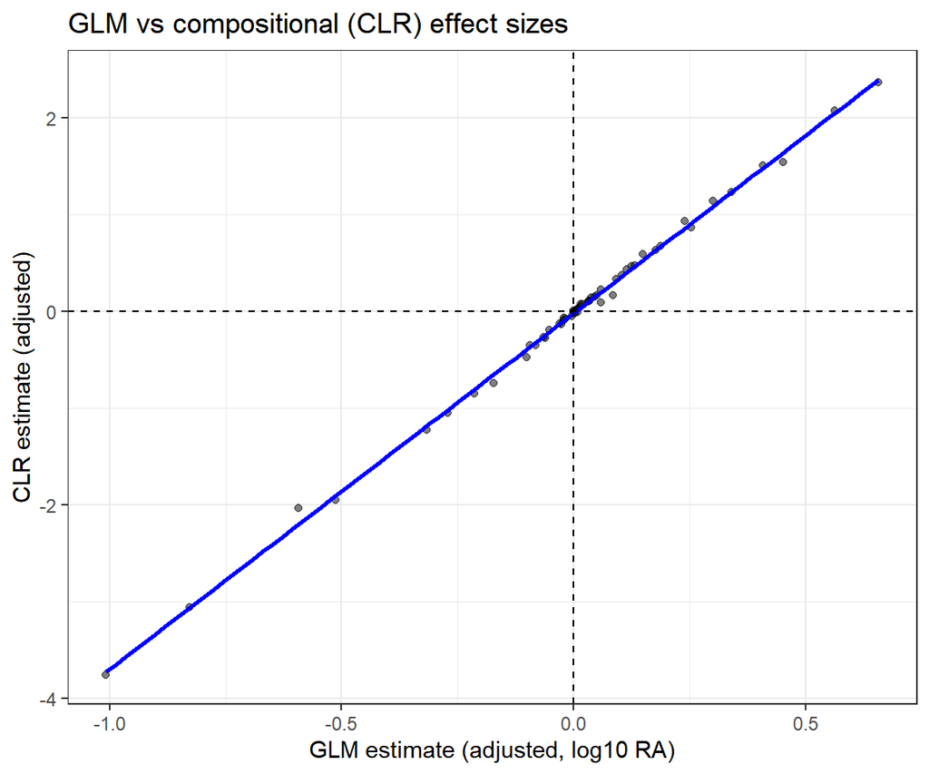

```r
comparison_results %>%
  ggplot(aes(x = glm_adj_estimate, y = clr_estimate)) +
    geom_point(alpha = 0.5) +
    geom_smooth(method = "lm", se = FALSE, color = "blue") +
    geom_hline(yintercept = 0, linetype = "dashed") +
    geom_vline(xintercept = 0, linetype = "dashed") +
    labs(x = "GLM estimate (adjusted, log10 RA)",
         y = "CLR estimate (adjusted)",
         title = "GLM vs compositional (CLR) effect sizes") +
    theme_bw()
```

> *Taught in: W21 reference Rmd §10 (scatter of adjusted GLM vs CLR estimates with an `lm` trend line).*

### Concordance across methods

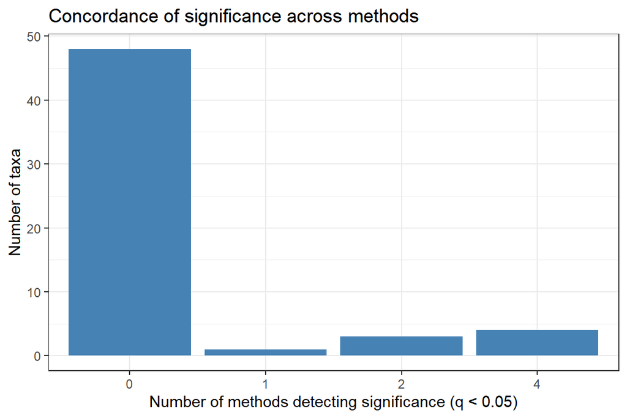

```r
comparison_results %>%
  mutate(
    sig_wilcox  = wilcox_q  < 0.05,
    sig_glm     = glm_q     < 0.05,
    sig_glm_adj = glm_adj_q < 0.05,
    sig_clr     = clr_q     < 0.05,
    n_methods_significant = sig_wilcox + sig_glm + sig_glm_adj + sig_clr
  ) %>%
  count(n_methods_significant) %>%
  filter(!is.na(n_methods_significant)) %>%
  ggplot(aes(x = factor(n_methods_significant), y = n)) +
    geom_col(fill = "steelblue") +
    labs(x = "Number of methods detecting significance (q < 0.05)",
         y = "Number of taxa",
         title = "Concordance of significance across methods") +
    theme_bw()
```

> *Taught in: W21 reference Rmd §10 (bar chart counting how many methods support each taxon).*

### Significance × direction heatmap

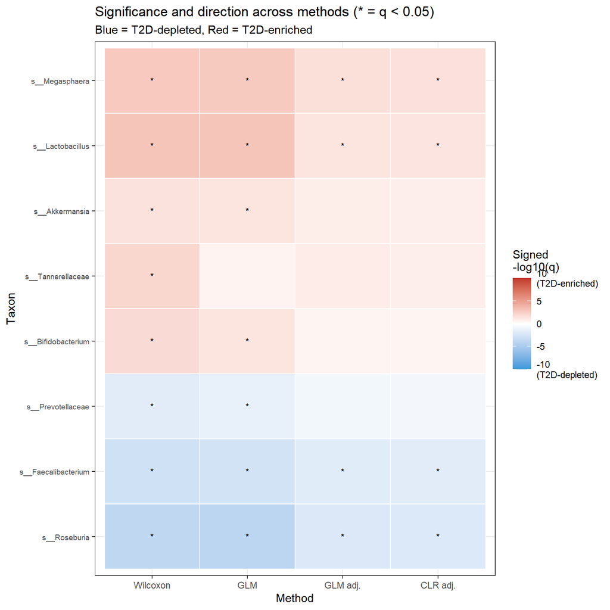

```r
heatmap_data <- comparison_results %>%
  filter(wilcox_q < 0.05 | glm_q < 0.05 | glm_adj_q < 0.05 | clr_q < 0.05) %>%
  mutate(label = Species) %>%
  select(label,
         wilcox_q, glm_q, glm_adj_q, clr_q,
         wilcox_log2fc, glm_estimate, glm_adj_estimate, clr_estimate) %>%
  pivot_longer(cols = c(wilcox_q, glm_q, glm_adj_q, clr_q),
               names_to = "method", values_to = "q_value") %>%
  mutate(
    direction = case_when(
      method == "wilcox_q"  ~ wilcox_log2fc,
      method == "glm_q"     ~ glm_estimate,
      method == "glm_adj_q" ~ glm_adj_estimate,
      method == "clr_q"     ~ clr_estimate
    ),
    signed_neg_log10_q = sign(direction) * pmin(-log10(q_value), 10),
    method = factor(method,
                    levels = c("wilcox_q", "glm_q", "glm_adj_q", "clr_q"),
                    labels = c("Wilcoxon", "GLM", "GLM adj.", "CLR adj."))
  )

taxon_order <- heatmap_data %>%
  group_by(label) %>%
  summarise(mean_signed = mean(signed_neg_log10_q, na.rm = TRUE), .groups = "drop") %>%
  arrange(mean_signed) %>%
  pull(label)

heatmap_data %>%
  mutate(label = factor(label, levels = taxon_order)) %>%
  ggplot(aes(x = method, y = label, fill = signed_neg_log10_q)) +
    geom_tile(color = "white", linewidth = 0.5) +
    geom_text(aes(label = ifelse(q_value < 0.05, "*", "")),
              color = "black", size = 3) +
    scale_fill_gradient2(
      low = "#3498DB", mid = "white", high = "#C0392B",
      midpoint = 0, limits = c(-10, 10),
      name = "Signed\n-log10(q)",
      breaks = c(-10, -5, 0, 5, 10),
      labels = c("-10\n(T2D-depleted)", "-5", "0", "5", "10\n(T2D-enriched)")
    ) +
    labs(x = "Method", y = "Taxon",
         title = "Significance and direction across methods (* = q < 0.05)",
         subtitle = "Blue = T2D-depleted, Red = T2D-enriched") +
    theme_bw() +
    theme(axis.text.y = element_text(size = 7))
```

> *Taught in: W21 reference Rmd §10 (signed `-log10(q)` heatmap across methods for taxa significant in ≥1 method, with `*` marking q < 0.05 and `scale_fill_gradient2` encoding direction).*

### Wilcoxon vs CLR — sign agreement

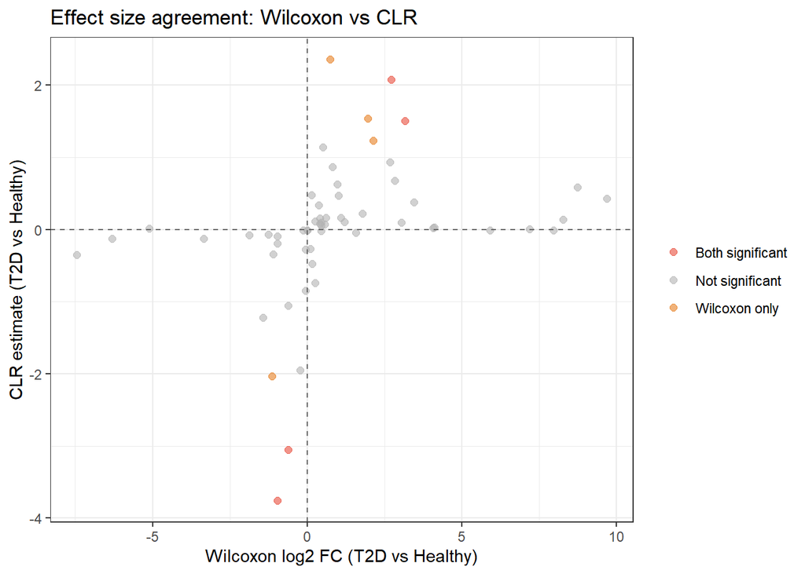

```r
comparison_results %>%
  mutate(
    sig_category = case_when(
      wilcox_q < 0.05 & clr_q < 0.05 ~ "Both significant",
      wilcox_q < 0.05                ~ "Wilcoxon only",
      clr_q < 0.05                   ~ "CLR only",
      TRUE                           ~ "Not significant"
    )
  ) %>%
  ggplot(aes(x = wilcox_log2fc, y = clr_estimate, color = sig_category)) +
    geom_point(alpha = 0.6, size = 2) +
    scale_color_manual(values = c(
      "Both significant" = "#E74C3C",
      "Wilcoxon only"    = "#E67E22",
      "CLR only"         = "#3498DB",
      "Not significant"  = "grey70"
    )) +
    geom_hline(yintercept = 0, linetype = "dashed", color = "grey40") +
    geom_vline(xintercept = 0, linetype = "dashed", color = "grey40") +
    labs(x = "Wilcoxon log2 FC (T2D vs Healthy)",
         y = "CLR estimate (T2D vs Healthy)",
         color = NULL,
         title = "Effect size agreement: Wilcoxon vs CLR") +
    theme_bw()
```

> *Taught in: W21 reference Rmd §10 (final method-comparison scatter: Wilcoxon log2FC vs CLR estimate, coloured by significance category — same-sign points indicate direction agreement).*

# Multivariate statistics

## PCA of CLR-transformed profiles

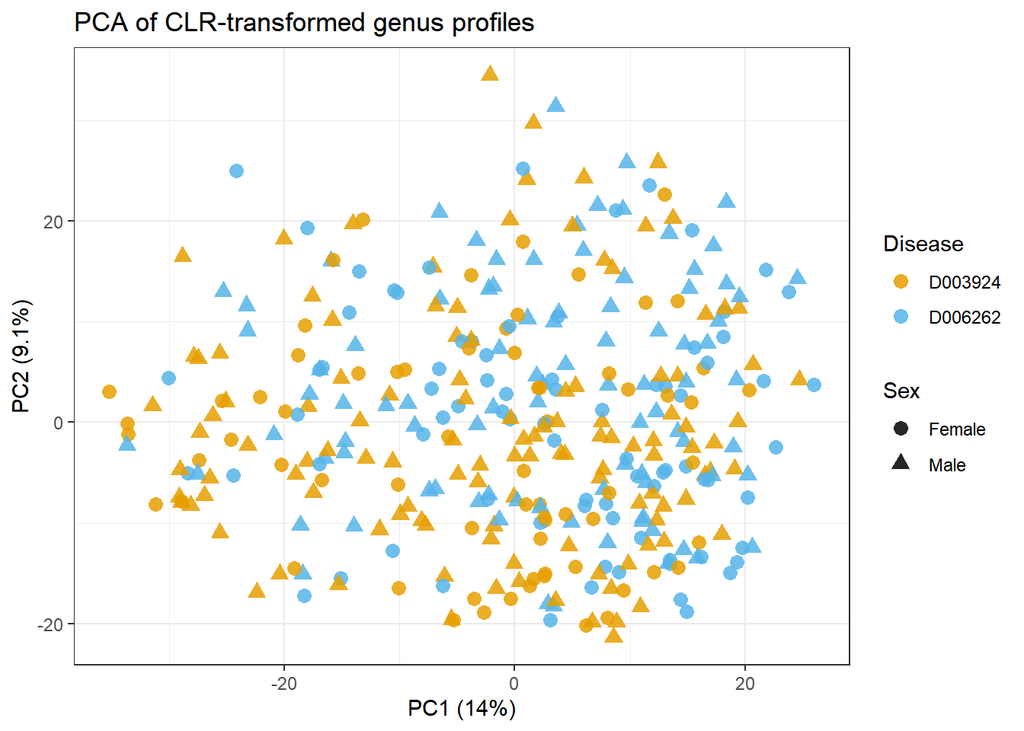

```r
clr_mat  <- otu_clr %>% as.matrix()
meta_pca <- meta_clr[rownames(clr_mat), ]

clr_pca <- prcomp(clr_mat, center = TRUE, scale. = FALSE)

pca_scores <- as.data.frame(clr_pca$x[, 1:2]) %>%
  rownames_to_column("sample_id") %>%
  left_join(meta_pca %>% rownames_to_column("sample_id"), by = "sample_id")

pca_var <- round(100 * clr_pca$sdev^2 / sum(clr_pca$sdev^2), 1)

pca_scores %>%
  ggplot(aes(x = PC1, y = PC2, color = Disease.MESH.ID, shape = Sex)) +
    geom_point(size = 3, alpha = 0.85) +
    scale_color_manual(values = c("D003924" = "#E69F00", "D006262" = "#56B4E9")) +
    scale_shape_manual(values = c("Female" = 16, "Male" = 17)) +
    labs(x = paste0("PC1 (", pca_var[1], "%)"),
         y = paste0("PC2 (", pca_var[2], "%)"),
         color = "Disease", shape = "Sex",
         title = "PCA of CLR-transformed genus profiles") +
    theme_bw()
```

> *Taught in: W21 reference Rmd §11 “PCA of CLR-transformed gut profiles” (`prcomp` on the CLR matrix, PC1/PC2 scores coloured by the grouping variable, `% variance` from `sdev^2`). Ordination of CLR/Aitchison data also W20-03 (PCoA/NMDS) and Alberdi reading §8 (whole-community structure).*

## Constrained ordination with RDA

```r
rda_disease <- rda(clr_mat ~ Disease.MESH.ID + Sex, data = meta_pca)
```

> *Taught in: W21 reference Rmd §12 “Constrained ordination with RDA” (`rda(clr_mat ~ predictors)`). The reference constrains by age + status; here by Disease + Sex. Constrained ordination on community data: Alberdi reading §8.*

### Permutation tests

```r
anova(rda_disease, permutations = 999)
```

```
## Permutation test for rda under reduced model
## Permutation: free
## Number of permutations: 999
##
## Model: rda(formula = clr_mat ~ Disease.MESH.ID + Sex, data = meta_pca)
##           Df Variance      F Pr(>F)
## Model      2    21.83 2.7686  0.001 ***
## Residual 356  1403.62
## ---
## Signif. codes:  0 '***' 0.001 '**' 0.01 '*' 0.05 '.' 0.1 ' ' 1
```

```r
anova(rda_disease, by = "term", permutations = 999)
```

```
## Permutation test for rda under reduced model
## Terms added sequentially (first to last)
## Permutation: free
## Number of permutations: 999
##
## Model: rda(formula = clr_mat ~ Disease.MESH.ID + Sex, data = meta_pca)
##                  Df Variance      F Pr(>F)
## Disease.MESH.ID   1    16.84 4.2720  0.001 ***
## Sex               1     4.99 1.2652  0.153
## Residual        356  1403.62
## ---
## Signif. codes:  0 '***' 0.001 '**' 0.01 '*' 0.05 '.' 0.1 ' ' 1
```

> *Taught in: W21 reference Rmd §12 (`anova(rda, permutations = 999)` for the whole model and `by = "term"` for each predictor). Permutation testing of constrained ordination also relates to PERMANOVA `adonis2` in W20-03.*

A significant disease term supports a community-level disease effect after accounting for sex.

### Top RDA1 taxa

```r
rda_site_scores_raw <- scores(rda_disease, display = "sites")
rda1_sign <- ifelse(
  mean(rda_site_scores_raw[meta_pca$Disease.MESH.ID == "D003924", "RDA1"], na.rm = TRUE) >=
    mean(rda_site_scores_raw[meta_pca$Disease.MESH.ID == "D006262", "RDA1"], na.rm = TRUE),
  1, -1
)

taxon_scores <- scores(rda_disease, display = "species")[, 1] * rda1_sign

rda_taxa <- tibble(
  taxon        = names(taxon_scores),
  rda1_loading = taxon_scores
) %>%
  arrange(desc(abs(rda1_loading)))
```

> *Taught in: W21 reference Rmd §12 (extract RDA1 taxon scores with `scores(..., display = "species")`, sign-orient RDA1 by group means, rank taxa by absolute loading).*

### RDA biplot

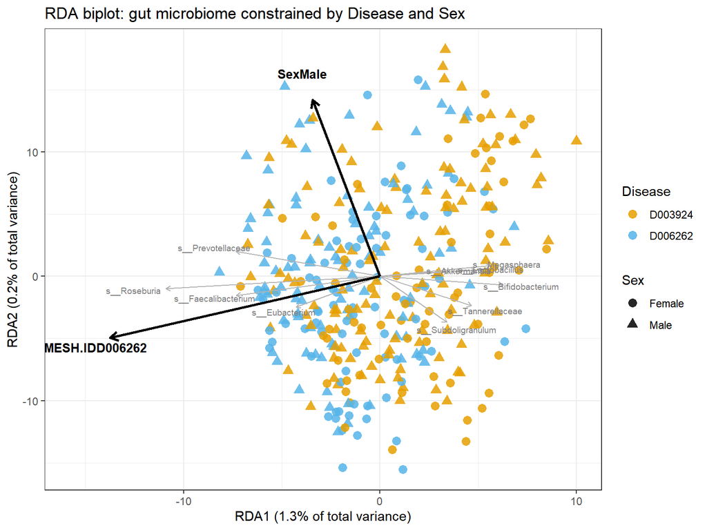

```r
eig <- rda_disease$CCA$eig
pct1 <- round(eig[1] / rda_disease$tot.chi * 100, 1)
pct2 <- round(eig[2] / rda_disease$tot.chi * 100, 1)

site_scores <- scores(rda_disease, display = "sites") %>%
  as.data.frame() %>%
  mutate(RDA1 = RDA1 * rda1_sign) %>%
  rownames_to_column("sample_id") %>%
  left_join(meta_pca %>% rownames_to_column("sample_id"), by = "sample_id")

biplot_scores <- scores(rda_disease, display = "bp") %>%
  as.data.frame() %>%
  mutate(RDA1 = RDA1 * rda1_sign) %>%
  rownames_to_column("variable")

top_species_scores <- scores(rda_disease, display = "species") %>%
  as.data.frame() %>%
  mutate(RDA1 = RDA1 * rda1_sign) %>%
  rownames_to_column("taxon") %>%
  inner_join(rda_taxa %>% head(10), by = "taxon") %>%
  left_join(tax_clr %>% rownames_to_column("taxon"), by = "taxon") %>%
  mutate(label = Species)

site_range    <- max(abs(c(site_scores$RDA1, site_scores$RDA2)))
arrow_scale   <- site_range * 0.8 / max(sqrt(biplot_scores$RDA1^2 + biplot_scores$RDA2^2))
species_scale <- site_range * 0.6 / max(sqrt(top_species_scores$RDA1^2 + top_species_scores$RDA2^2))

biplot_scores      <- biplot_scores      %>% mutate(RDA1 = RDA1 * arrow_scale,   RDA2 = RDA2 * arrow_scale)
top_species_scores <- top_species_scores %>% mutate(RDA1 = RDA1 * species_scale, RDA2 = RDA2 * species_scale)

ggplot() +
  geom_point(data = site_scores,
             aes(x = RDA1, y = RDA2, color = Disease.MESH.ID, shape = Sex),
             size = 3, alpha = 0.85) +
  geom_segment(data = top_species_scores,
               aes(x = 0, y = 0, xend = RDA1, yend = RDA2),
               arrow = arrow(length = unit(0.15, "cm")),
               color = "grey70", linewidth = 0.5) +
  geom_text(data = top_species_scores,
            aes(x = RDA1 * 1.15, y = RDA2 * 1.15, label = label),
            size = 2.5, color = "grey50") +
  geom_segment(data = biplot_scores,
               aes(x = 0, y = 0, xend = RDA1, yend = RDA2),
               arrow = arrow(length = unit(0.25, "cm")),
               color = "black", linewidth = 1) +
  geom_text(data = biplot_scores,
            aes(x = RDA1 * 1.15, y = RDA2 * 1.15, label = variable),
            size = 3.5, fontface = "bold", color = "black") +
  scale_color_manual(values = c("D003924" = "#E69F00", "D006262" = "#56B4E9")) +
  scale_shape_manual(values = c("Female" = 16, "Male" = 17)) +
  labs(x = paste0("RDA1 (", pct1, "% of total variance)"),
       y = paste0("RDA2 (", pct2, "% of total variance)"),
       color = "Disease", shape = "Sex",
       title = "RDA biplot: gut microbiome constrained by Disease and Sex") +
  theme_bw()
```

> *Taught in: W21 reference Rmd §12 (RDA biplot overlaying site scores, constraint arrows (`display = "bp"`) and the top species arrows, with the same arrow/species rescaling to ~80%/60% of the site range).*

### Top 20 taxa by RDA1 loading

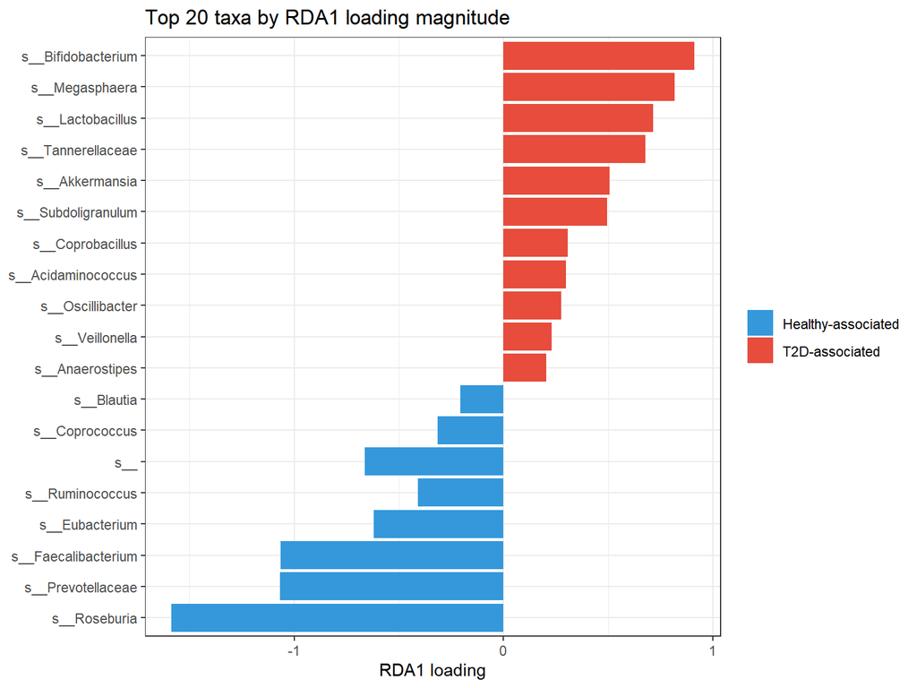

```r
rda_taxa %>%
  head(20) %>%
  left_join(tax_clr %>% rownames_to_column("taxon"), by = "taxon") %>%
  mutate(
    label     = Species,
    direction = ifelse(rda1_loading > 0, "T2D-associated", "Healthy-associated")
  ) %>%
  ggplot(aes(x = reorder(label, rda1_loading), y = rda1_loading, fill = direction)) +
    geom_col() +
    coord_flip() +
    scale_fill_manual(values = c("T2D-associated"     = "#E74C3C",
                                 "Healthy-associated" = "#3498DB")) +
    labs(x = NULL, y = "RDA1 loading", fill = NULL,
         title = "Top 20 taxa by RDA1 loading magnitude") +
    theme_bw()
```

> *Taught in: W21 reference Rmd §12 (bar chart of the top 20 taxa by RDA1 loading, coloured by which group side they associate with).*

### RDA loadings vs CLR univariate estimates

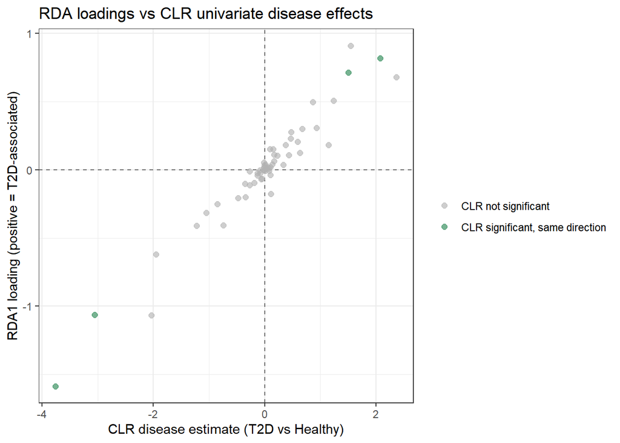

```r
rda_clr_comparison <- rda_taxa %>%
  left_join(
    clr_disease_adjusted_sex_results %>%
      select(taxon, Genus, Species,
             clr_estimate = estimate,
             clr_q = q_value),
    by = "taxon"
  ) %>%
  mutate(
    direction_agreement = sign(rda1_loading) == sign(clr_estimate),
    clr_result = case_when(
      clr_q < 0.05 & direction_agreement ~ "CLR significant, same direction",
      clr_q < 0.05                       ~ "CLR significant, opposite direction",
      TRUE                               ~ "CLR not significant"
    )
  )

rda_clr_comparison %>%
  ggplot(aes(x = clr_estimate, y = rda1_loading, color = clr_result)) +
    geom_hline(yintercept = 0, linetype = "dashed", color = "grey40") +
    geom_vline(xintercept = 0, linetype = "dashed", color = "grey40") +
    geom_point(alpha = 0.65, size = 2) +
    scale_color_manual(values = c(
      "CLR significant, same direction"     = "#2E8B57",
      "CLR significant, opposite direction" = "#E67E22",
      "CLR not significant"                 = "grey70"
    )) +
    labs(x = "CLR disease estimate (T2D vs Healthy)",
         y = "RDA1 loading (positive = T2D-associated)",
         color = NULL,
         title = "RDA loadings vs CLR univariate disease effects") +
    theme_bw()
```

> *Taught in: W21 reference Rmd §12 (scatter linking multivariate RDA1 loadings to the univariate CLR estimates, coloured by significance + direction agreement).*

### Top 20 RDA loading taxa with their CLR statistics

```r
rda_clr_comparison %>%
  arrange(desc(abs(rda1_loading))) %>%
  select(Genus, Species, rda1_loading, clr_estimate, clr_q, direction_agreement) %>%
  head(20)
```

```
## # A tibble: 20 × 6
##    Genus           Species rda1_loading clr_estimate   clr_q direction_agreement
##    <chr>           <chr>          <dbl>        <dbl>   <dbl> <lgl>
##  1 g__Lachnospira… s__Ros…       -1.59        -3.75  0.00878 TRUE
##  2 g__Bacteroidal… s__Pre…       -1.07        -2.03  0.185   TRUE
##  3 g__Ruminococca… s__Fae…       -1.06        -3.05  0.0177  TRUE
##  4 g__Bifidobacte… s__Bif…        0.911        1.54  0.292   TRUE
##  5 g__Veillonella… s__Meg…        0.817        2.08  0.0264  TRUE
##  6 g__Lactobacill… s__Lac…        0.713        1.51  0.0456  TRUE
##  7 g__Bacteroidal… s__Tan…        0.679        2.36  0.141   TRUE
##  8 g__Eubacteriac… s__Eub…       -0.621       -1.95  0.206   TRUE
##  9 g__Akkermansia… s__Akk…        0.507        1.24  0.141   TRUE
## 10 g__Ruminococca… s__Sub…        0.495        0.864 0.746   TRUE
## 11 g__Haemophilus  s__           -0.410       -1.22  0.141   TRUE
## 12 g__Ruminococca… s__Rum…       -0.408       -0.743 0.847   TRUE
## 13 g__Lachnospira… s__Cop…       -0.315       -1.05  0.282   TRUE
## 14 g__Erysipelotr… s__Cop…        0.307        0.931 0.141   TRUE
## 15 g__Acidaminoco… s__Aci…        0.299        0.674 0.287   TRUE
## 16 g__Oscillospir… s__Osc…        0.276        0.478 0.694   TRUE
## 17 g__Klebsiella   s__           -0.252       -0.852 0.567   TRUE
## 18 g__Veillonella… s__Vei…        0.231        0.470 0.766   TRUE
## 19 g__Lachnospira… s__Bla…       -0.208       -0.475 0.952   TRUE
## 20 g__Lachnospira… s__Ana…        0.205        0.590 0.141   TRUE
```

> *Taught in: W21 reference Rmd §12 (final table of the top 20 RDA-loading taxa with their CLR estimate, q-value and direction agreement).*